# Tables and figures from: Emotional and physical abuse have dissociable impacts on punishment learning and task engagement during adolescence

## Table 3 (main text). Effects of Adversity Subtypes on Learning Metric Development

Estimates (unstandardized b) and 95% CIs from Model 4 for each CTQ subscale. Stars show uncorrected p-values; bold shows effects that survive FDR correction. “J-N” rows give the CTQ scores at which the age slope is significant.

|  | Emotional Abuse (EA) | Physical Abuse (PA) | Sexual Abuse (SA) | Emotional Neglect (EN) | Physical Neglect (PN) |
| --- | --- | --- | --- | --- | --- |
| **Good Deck Proportion (last block)** |  |  |  |  |  |
| Adversity Baseline Effect | -.000 [-.009 – .009] | -.007 [-.017 – .002] | -.024 [-.049 – .001] | .001 [-.007 – .009] | -.005 [-.015 – .004] |
| Interaction of Adversity × Age | -.002 [-.006 – .002] | **-.009 ***** **[-.014 – -.004]** | -.013 [-.028 – .001] | -.002 [-.005 – .002] | -.005 * [-.010 – -.001] |
| J-N Adversity Levels of Sig |  | < 5.64; > 9.18 *** |  |  |  |
| **Bad Deck Proportion (last block)** |  |  |  |  |  |
| Adversity Baseline Effect | -.006 [-.015 – .004] | -.004 [-.014 – .006] | -.022 [-.047 – .003] | -.005 [-.013 – .003] | -.009 [-.019 – .001] |
| Interaction of Adversity × Age | .003 [-.002 – .008] | -.003 [-.010 – .003] | -.009 [-.026 – .008] | .002 [-.002 – .006] | -.001 [-.007 – .005] |
| **Net Performance (last block)** |  |  |  |  |  |
| Adversity Baseline Effect | .005 [-.004 – .015] | -.004 [-.014 – .006] | -.006 [-.032 – .020] | .006 [-.003 – .014] | .004 [-.006 – .014] |
| Interaction of Adversity × Age | -.005 [-.009 – .000] | -.005 [-.011 – .002] | -.004 [-.022 – .013] | -.004 [-.008 – .000] | -.003 [-.009 – .003] |
| **Go Bias (βb)** |  |  |  |  |  |
| Adversity Baseline Effect | .007 [-.016 – .031] | .001 [-.028 – .030] | .018 [-.054 – .089] | .012 [-.008 – .032] | .011 [-.014 – .036] |
| Interaction of Adversity × Age | -.008 [-.023 – .008] | **-.022 **** **[-.037 – -.006]** | -.032 [-.084 – .020] | .001 [-.012 – .014] | .000 [-.017 – .018] |
| J-N Adversity Levels of Sig |  | < 6.28; > 14.45 ** |  |  |  |
| Interaction of Adversity × Age² | .001 [-.003 – .005] | -.001 [-.008 – .006] | .001 [-.024 – .026] | -.003 [-.007 – .001] | -.007 * [-.012 – -.001] |
| **Reward Learning Rate (Arew)** |  |  |  |  |  |
| Adversity Baseline Effect | -.006 [-.017 – .006] | -.010 [-.021 – .002] | -.009 [-.039 – .022] | -.005 [-.014 – .005] | -.013 * [-.024 – -.001] |
| Interaction of Adversity × Age | -.002 [-.007 – .003] | -.006 [-.013 – .001] | -.015 [-.034 – .005] | .001 [-.004 – .005] | .000 [-.006 – .006] |
| **Punishment Learning Rate (Apun)** |  |  |  |  |  |
| Adversity Baseline Effect | .007 [-.006 – .019] | -.003 [-.016 – .010] | .017 [-.016 – .050] | .003 [-.008 – .013] | .006 [-.007 – .019] |
| Interaction of Adversity × Age | **-.009 **** **[-.015 – -.003]** | -.006 [-.014 – .002] | -.012 [-.035 – .010] | -.004 [-.010 – .001] | -.003 [-.010 – .005] |
| J-N Adversity Levels of Sig | < 7.85; > 18.68 ** |  |  |  |  |
| **Averaged Single Learning Rate ((Arew + Apun)/2)** |  |  |  |  |  |
| Adversity Baseline Effect | .000 [-.008 – .009] | -.006 [-.015 – .002] | .004 [-.018 – .026] | -.001 [-.008 – .006] | -.003 [-.012 – .005] |
| Interaction of Adversity × Age | -.005 * [-.009 – -.001] | -.006 * [-.011 – -.000] | -.013 [-.028 – .002] | -.002 [-.005 – .002] | -.001 [-.006 – .004] |
| **Win/Loss Frequency Sensitivity (βf)** |  |  |  |  |  |
| Adversity Baseline Effect | .034 [-.116 – .185] | .023 [-.135 – .182] | .442 * [.050 – .834] | .069 [-.056 – .195] | .090 [-.064 – .244] |
| Interaction of Adversity × Age | .006 [-.078 – .090] | .000 [-.107 – .107] | -.116 [-.399 – .167] | -.039 [-.111 – .033] | .035 [-.066 – .136] |

## Figure 1 (main text). Effects of Adversity Subtypes on Learning Metric Development Surviving FDR Correction

Same plotting code as the paper’s figure. Top: model-predicted trajectories for youth with low (mean − 1 SD) and high (mean + 1 SD) levels of the CTQ subscale, with each participant’s data in grey. Bottom: Johnson-Neyman plot of the age-related slope across levels of adversity severity (blue = significant positive slope, grey = not significant, red = significant negative slope; the solid vertical line marks the moderate-severity cutoff; dashed vertical lines mark the boundaries of the region of significance), with an arrow showing low to high adversity. (A) Emotional abuse and Punishment Learning Rate. (B) Physical abuse and Go Bias. (C) Physical abuse and Good Deck Proportion (last block).

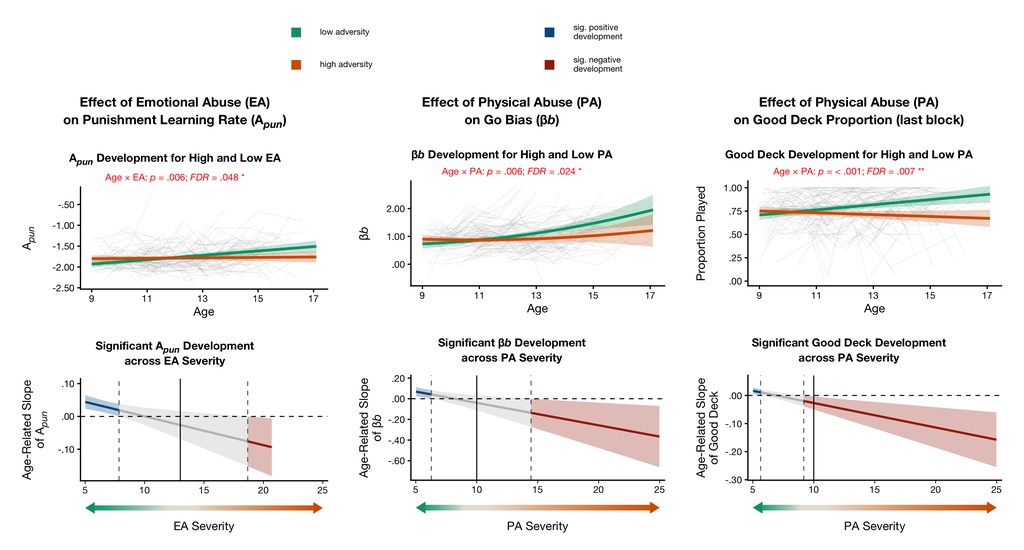

## Supplemental Table 1. Demographic information and descriptive statistics across all five timepoints

For each timepoint: sample size, mean (SD) or percentage for demographics and, at Timepoint 1 only, the CTQ subscale scores, the Minimization/Denial scale, and the association of each demographic variable with the CTQ Total score (linear regression for age and IQ; logistic regression for sex and racial minority status).

| Variable | Timepoint 1 | Timepoint 2 | Timepoint 3 | Timepoint 4 | Timepoint 5 | Association with CTQ Total score (Timepoint 1) |
| --- | --- | --- | --- | --- | --- | --- |
| N participants | 166 | 130 | 107 | 71 | 54 |  |
| Age (years), mean (SD) | 10.99 (1.48) | 11.84 (1.52) | 12.73 (1.52) | 13.51 (1.53) | 14.14 (1.47) | β = 0.45; p = .378 |
| Sex assigned at birth (female) | 56.6% | 60.0% | 59.8% | 60.6% | 55.6% | β = -0.02; p = .224 |
| K-BIT nonverbal IQ, mean (SD) | 101.32 (14.65) | 100.52 (15.43) | 101.04 (14.93) | 101.45 (14.46) | 100.04 (16.49) | β = -0.01; p = .874 |
| In-lab administration (E-Prime) | 100.0% | 100.0% | 99.1% | 84.5% | 31.5% |  |
| Racial minority (non-White) | 60% (of 84% reporting race) |  |  |  |  | β = -0.00; p = .990 |
| **Racial breakdown among those reporting race** |  |  |  |  |  |  |
| White | 40.0% |  |  |  |  |  |
| Black/African American | 45.0% |  |  |  |  |  |
| Asian | 0.7% |  |  |  |  |  |
| Multiracial | 12.1% |  |  |  |  |  |
| Other | 2.1% |  |  |  |  |  |
| **CTQ subscale scores, mean (SD)** |  |  |  |  |  |  |
| Emotional Neglect (EN) | 7.43 (3.50) |  |  |  |  |  |
| Emotional Abuse (EA) | 6.89 (2.87) |  |  |  |  |  |
| Physical Abuse (PA) | 6.10 (2.64) |  |  |  |  |  |
| Physical Neglect (PN) | 6.91 (2.51) |  |  |  |  |  |
| Sexual Abuse (SA) | 5.20 (1.03) |  |  |  |  |  |
| **CTQ Minimization/Denial scale: % of participants at each score** |  |  |  |  |  |  |
| score = 0 | 28.8% |  |  |  |  |  |
| score = 1 | 31.9% |  |  |  |  |  |
| score = 2 | 25.8% |  |  |  |  |  |
| score = 3 | 13.5% |  |  |  |  |  |

## Supplemental Table 2. Sample descriptive statistics related to the CTQ subscales

Participants (n = 166) are counted using baseline CTQ subscale scores. “Above the minimum” = any endorsement (score > 5). “+1 SD” = more than one standard deviation above the sample mean. Clinical cutoffs are the moderate-to-severe cutoffs of Bernstein & Fink (1998). “Observations” = participant-waves (out of 528) contributed by participants above the minimum.

| CTQ scale | Participants above the minimum score (any endorsement) | Participants above +1 SD | Participants at or above clinical cutoff | Observations contributed by participants above the minimum |
| --- | --- | --- | --- | --- |
| Emotional Abuse (EA) | 85 (51%) | 25 | 11 (cutoff ≥ 13) | 268 |
| Physical Abuse (PA) | 54 (33%) | 15 | 11 (cutoff ≥ 10) | 168 |
| Sexual Abuse (SA) | 8 (5%) | 7 | 5 (cutoff ≥ 8) | 21 |
| Emotional Neglect (EN) | 103 (62%) | 21 | 9 (cutoff ≥ 15) | 333 |
| Physical Neglect (PN) | 89 (54%) | 18 | 18 (cutoff ≥ 10) | 290 |

## Supplemental Table 4. Model recovery for the one- versus two-learning-rate PoP-ORL models

Not reproduced here: model recovery requires simulating data and fitting the Stan models. Code available upon request.

## Supplemental Table 5. Baseline correlations among the CTQ adversity predictors, covariates, and learning metrics

Pearson correlations at baseline (T1; n = 166). Stars mark uncorrected p-values (* p < .05, ** p < .01, *** p < .001). Sex is coded 0 = male, 1 = female.

### Supplemental Table 5.1. Correlations among the CTQ adversity predictors and covariates

Variable

1

2

3

4

5

6

7

8

9

10

1. Abuse Composite

—

2. Neglect Composite

.65***

—

3. Emotional Abuse

.87***

.48***

—

4. Physical Abuse

.87***

.56***

.57***

—

5. Sexual Abuse

.56***

.61***

.30***

.42***

—

6. Emotional Neglect

.61***

.92***

.49***

.51***

.54***

—

7. Physical Neglect

.53***

.84***

.35***

.48***

.55***

.57***

—

8. Age (years)

.05

.07

.14

-.04

.01

.14

-.04

—

9. Nonverbal IQ (K-BIT)

.04

-.07

.04

.05

-.01

-.13

.04

-.07

—

10. Sex (0 = male, 1 = female)

-.12

-.06

-.14

-.10

.00

-.05

-.06

-.13

.05

—

### Supplemental Table 5.2. Correlations between the CTQ adversity predictors and the learning metrics

| Variable | Good Deck Proportion | Bad Deck Proportion | Net Performance | Go Bias (βb) | Reward Learning Rate (Arew) | Punishment Learning Rate (Apun) | Averaged Single Learning Rate ((Arew + Apun)/2) | Win/Loss Frequency Sensitivity (βf) |
| --- | --- | --- | --- | --- | --- | --- | --- | --- |
| Abuse Composite | .05 | .03 | .02 | .13 | .02 | .02 | .03 | .05 |
| Neglect Composite | -.00 | -.06 | .06 | .03 | -.01 | .04 | .02 | .12 |
| Emotional Abuse | .07 | -.02 | .09 | .09 | -.01 | .05 | .04 | .06 |
| Physical Abuse | .05 | .07 | -.02 | .13 | .02 | -.03 | -.01 | .01 |
| Sexual Abuse | -.05 | .06 | -.10 | .09 | .06 | .01 | .06 | .08 |
| Emotional Neglect | .04 | -.03 | .07 | .05 | -.02 | -.02 | -.03 | .07 |
| Physical Neglect | -.06 | -.09 | .03 | .00 | -.00 | .11 | .10 | .17* |

### Supplemental Table 5.3. Correlations among the learning metrics

Variable

1

2

3

4

5

6

7

8

1. Good Deck Proportion

—

2. Bad Deck Proportion

.45***

—

3. Net Performance

.51***

-.54***

—

4. Go Bias (βb)

.61***

.39***

.20*

—

5. Reward Learning Rate (Arew)

.42***

.56***

-.15

.32***

—

6. Punishment Learning Rate (Apun)

-.03

-.68***

.63***

.12

-.29***

—

7. Averaged Single Learning Rate ((Arew + Apun)/2)

.29***

-.20*

.46***

.35***

.49***

.69***

—

8. Win/Loss Frequency Sensitivity (βf)

.35***

-.07

.39***

.06

.32***

.19*

.42***

—

## Supplemental Table 6. Mean percentage of “plays” for each deck across each wave

Mean (SD) percentage of each deck’s 30 cards that participants chose to play, by wave (participant-wave level).

| Deck | T1 | T2 | T3 | T4 | T5 |
| --- | --- | --- | --- | --- | --- |
| Deck A: bad, frequent losses | 64.4% (16.7) | 64.7% (18.6) | 64.9% (18.6) | 62.0% (19.3) | 61.7% (22.0) |
| Deck B: bad, infrequent losses | 70.9% (16.0) | 71.6% (15.7) | 72.9% (17.5) | 69.1% (18.4) | 71.4% (22.5) |
| Deck C: good, frequent losses | 71.0% (14.9) | 73.8% (15.2) | 78.5% (17.2) | 74.4% (16.6) | 80.8% (19.9) |
| Deck D: good, infrequent losses | 72.5% (15.5) | 74.6% (15.8) | 77.9% (15.6) | 76.7% (17.9) | 78.1% (21.6) |

## Supplemental Figure 1. Distribution of “plays” for each deck across each wave

Bars show the percentage of participants at each wave in each 10-point bin of the proportion of the deck’s cards played.

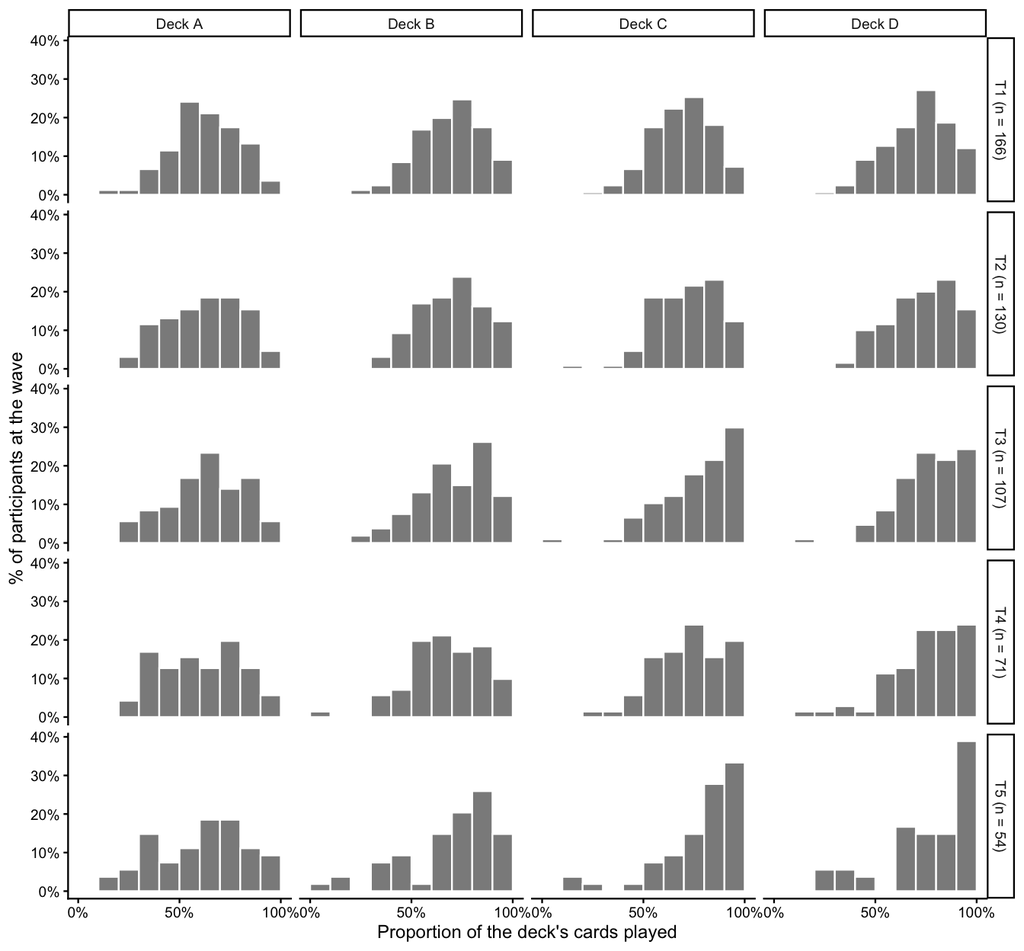

## Supplemental Table 7. Relationship between the learning parameters and Net Performance

Change in Net Performance (last block, percentage points) per 1 SD higher parameter, from multilevel models adjusted for age, nonverbal IQ, sex, and administration mode. “Alone” = each parameter entered by itself; “Together” = all four parameters entered together.

| Learning Parameter | Alone: b [95% CI] | p-value | Together: b [95% CI] | p-value |
| --- | --- | --- | --- | --- |
| Reward Learning Rate (Arew) | -0.91 [-2.86, 1.04] | .360 | -1.86 [-3.38, -0.35] | .016 |
| Punishment Learning Rate (Apun) | 14.54 [12.91, 16.17] | <.001 | 13.17 [11.65, 14.70] | <.001 |
| Win/Loss Frequency Sensitivity (βf) | 9.22 [7.23, 11.22] | <.001 | 7.71 [6.10, 9.32] | <.001 |
| Go Bias (βb) | 4.70 [2.68, 6.72] | <.001 | 1.29 [-0.24, 2.81] | .100 |

Marginal R² = 11.3% for the model with age and covariates only and 54.1% with the four learning parameters.

## Supplemental Figure 2. Influence of model parameters on choice behavior and task performance

Not reproduced here: this figure comes from simulating choices from the PoP-ORL model, which requires running Stan code. Code available upon request.

## Supplemental Table 8. Summary of unconditional growth models

Age effects from the unconditional growth models (age only, no covariates) for the proportion of cards played from each deck, the traditional scores (last block and full task), and the model-based metrics. Age² is shown only where the quadratic model was retained (likelihood-ratio test, p < .05). FDR correction is across the eight primary metrics (Age: eight linear tests; Age²: eight curvature tests); deck-level models are uncorrected.

| Outcome | Effect | b | 95% CI | p-value | FDR p-value |
| --- | --- | --- | --- | --- | --- |
| **Proportion of cards played from each deck (computed from all trials of the task)** |  |  |  |  |  |
| Deck A: bad, frequent losses | Age | -.012 | [-.023 – -.001] | .030 | — |
| Deck B: bad, infrequent losses | Age | -.008 | [-.018 – .002] | .141 | — |
| Deck C: good, frequent losses | Age | .013 | [.003 – .022] | .009 | — |
| Deck D: good, infrequent losses | Age | .008 | [-.002 – .018] | .114 | — |
| **Traditional scoring metrics (computed from the last block of the task)** |  |  |  |  |  |
| Good Deck Proportion | Age | .013 | [.003 – .023] | .014 | .016 |
| Bad Deck Proportion | Age | -.020 | [-.033 – -.006] | .005 | .009 |
| Net Performance | Age | .032 | [.018 – .045] | <.001 | <.001 |
| **Traditional scoring metrics (computed from all trials of the task; sensitivity analysis)** |  |  |  |  |  |
| Good Deck Proportion | Age | .011 | [.003 – .020] | .012 | .016 |
| Bad Deck Proportion | Age | -.009 | [-.018 – .000] | .062 | .071 |
| Net Performance | Age | .020 | [.011 – .028] | <.001 | <.001 |
| **PoP-ORL model-based metrics** |  |  |  |  |  |
| Go Bias (βb) | Age | .059 | [.017 – .101] | .007 | .011 |
| Go Bias (βb) | Age² | .018 | [.006 – .030] | .004 | .033 |
| Reward Learning Rate (Arew) | Age | -.040 | [-.054 – -.026] | <.001 | <.001 |
| Punishment Learning Rate (Apun) | Age | .023 | [.006 – .041] | .011 | .014 |
| Averaged Single Learning Rate ((Arew + Apun)/2) | Age | -.010 | [-.022 – .002] | .094 | .094 |
| Win/Loss Frequency Sensitivity (βf) | Age | .563 | [.317 – .810] | <.001 | <.001 |

## Supplemental Table 9. Full nested model results

Models 1-4 for each learning metric and each CTQ predictor (56 sub-tables, 9.1-9.56). Model 1 = unconditional linear growth; Model 2 = unconditional quadratic growth; Model 3 = winning growth shape plus covariates (nonverbal IQ, sex, administration mode); Model 4 = Model 3 plus the CTQ predictor and its interaction with age (and age² if the quadratic shape won). Cells show unstandardized b, uncorrected significance stars (* p < .05, ** p < .01, *** p < .001), and the 95% CI. A “—” in the τ₁₁ row means the random age slope was dropped because the fit was singular. J-N = Johnson-Neyman: CTQ scores (raw scale) at which the age slope is significant, shown for age interactions with p < .05.

### Supplemental Table 9.1. Good Deck Proportion (Last Block) Predicted by Abuse Composite

|  | Model 1 | Model 2 | Model 3 | Model 4 |
| --- | --- | --- | --- | --- |
| **Fixed Effects** |  |  |  |  |
| Constant | .744 *** [.719 – .769] | .746 *** [.720 – .772] | .813 *** [.743 – .882] | .809 *** [.740 – .879] |
| Age | .013 * [.003 – .023] | .017 * [.001 – .032] | .009 [-.002 – .020] | .009 [-.002 – .020] |
| Age² | — | -.001 [-.006 – .003] | — | — |
| K-BIT Nonverbal Standard IQ | — | — | .001 [-.000 – .003] | .001 [-.000 – .003] |
| Child Sex | — | — | -.038 [-.083 – .007] | -.039 [-.084 – .006] |
| On-site Administration | — | — | -.046 [-.104 – .013] | -.042 [-.099 – .016] |
| Abuse Composite Baseline Effect | — | — | — | -.002 [-.007 – .003] |
| Age × Abuse Composite | — | — | — | -.003 * [-.005 – -.000] |
| J-N Adversity Levels of Sig | — | — | — | < 17.07; > 48.76 |
| **Random Effects** |  |  |  |  |
| σ² | 0.03 | 0.03 | 0.03 | 0.03 |
| τ₀₀ (id) | 0.01 | 0.01 | 0.01 | 0.01 |
| τ₁₁ (id.age) | — | 0.00 | 0.00 | — |
| N (id) | 166 | 166 | 166 | 166 |
| **Fit Statistics** |  |  |  |  |
| AIC | -247.9 | -244.2 | -246.4 | -251.4 |
| BIC | -230.8 | -218.6 | -212.2 | -213.0 |
| Log-Likelihood | 128.0 | 128.1 | 131.2 | 134.7 |
| Deviance | -255.9 | -256.2 | -262.4 | -269.4 |
| **Model Comparisons** |  |  |  |  |
| Compared to Model 1 |  | χ²(1) = 0.34 | χ²(4) = 6.46 | χ²(5) = 13.52 * |
| Compared to Model 2 |  |  |  |  |
| Compared to Model 3 |  |  |  | χ²(1) = 7.05 ** |
| ICC | 0.31 | 0.31 | 0.29 | 0.29 |
| Conditional R² | 0.32 | 0.32 | 0.31 | 0.32 |
| Marginal R² | 0.01 | 0.01 | 0.03 | 0.05 |

### Supplemental Table 9.2. Bad Deck Proportion (Last Block) Predicted by Abuse Composite

|  | Model 1 | Model 2 | Model 3 | Model 4 |
| --- | --- | --- | --- | --- |
| **Fixed Effects** |  |  |  |  |
| Constant | .680 *** [.654 – .705] | .681 *** [.655 – .708] | .737 *** [.659 – .815] | .739 *** [.661 – .817] |
| Age | -.020 ** [-.033 – -.006] | -.017 [-.035 – .001] | -.025 *** [-.039 – -.011] | -.025 *** [-.039 – -.011] |
| Age² | — | -.001 [-.007 – .004] | — | — |
| K-BIT Nonverbal Standard IQ | — | — | -.002 ** [-.004 – -.001] | -.002 ** [-.004 – -.001] |
| Child Sex | — | — | -.028 [-.076 – .021] | -.032 [-.080 – .017] |
| On-site Administration | — | — | -.040 [-.108 – .027] | -.040 [-.108 – .028] |
| Abuse Composite Baseline Effect | — | — | — | -.003 [-.008 – .002] |
| Age × Abuse Composite | — | — | — | .000 [-.003 – .003] |
| **Random Effects** |  |  |  |  |
| σ² | 0.03 | 0.03 | 0.03 | 0.03 |
| τ₀₀ (id) | 0.01 | 0.01 | 0.01 | 0.01 |
| τ₁₁ (id.age) | 0.00 | 0.00 | 0.00 | 0.00 |
| N (id) | 166 | 166 | 166 | 166 |
| **Fit Statistics** |  |  |  |  |
| AIC | -139.7 | -138.0 | -146.1 | -143.4 |
| BIC | -118.4 | -112.4 | -112.0 | -100.7 |
| Log-Likelihood | 74.9 | 75.0 | 81.1 | 81.7 |
| Deviance | -149.7 | -150.0 | -162.1 | -163.4 |
| **Model Comparisons** |  |  |  |  |
| Compared to Model 1 |  | χ²(1) = 0.23 | χ²(3) = 12.37 ** | χ²(5) = 13.69 * |
| Compared to Model 2 |  |  |  |  |
| Compared to Model 3 |  |  |  | χ²(2) = 1.33 |
| ICC | 0.23 | 0.23 | 0.21 | 0.20 |
| Conditional R² | 0.39 | 0.39 | 0.39 | 0.39 |
| Marginal R² | 0.03 | 0.03 | 0.06 | 0.07 |

### Supplemental Table 9.3. Net Performance (Good Proportion – Bad Proportion) (Last Block) Predicted by Abuse Composite

|  | Model 1 | Model 2 | Model 3 | Model 4 |
| --- | --- | --- | --- | --- |
| **Fixed Effects** |  |  |  |  |
| Constant | .068 *** [.041 – .094] | .068 *** [.040 – .095] | .096 * [.015 – .177] | .093 * [.013 – .174] |
| Age | .032 *** [.018 – .045] | .031 ** [.012 – .050] | .032 *** [.018 – .046] | .032 *** [.018 – .046] |
| Age² | — | .000 [-.006 – .006] | — | — |
| K-BIT Nonverbal Standard IQ | — | — | .004 *** [.002 – .005] | .004 *** [.002 – .005] |
| Child Sex | — | — | -.016 [-.063 – .032] | -.015 [-.062 – .033] |
| On-site Administration | — | — | -.019 [-.090 – .052] | -.016 [-.087 – .055] |
| Abuse Composite Baseline Effect | — | — | — | .000 [-.005 – .005] |
| Age × Abuse Composite | — | — | — | -.003 [-.005 – .000] |
| **Random Effects** |  |  |  |  |
| σ² | 0.04 | 0.04 | 0.04 | 0.04 |
| τ₀₀ (id) | 0.01 | 0.01 | 0.01 | 0.01 |
| τ₁₁ (id.age) | 0.00 | 0.00 | 0.00 | 0.00 |
| N (id) | 166 | 166 | 166 | 166 |
| **Fit Statistics** |  |  |  |  |
| AIC | -67.4 | -65.4 | -81.5 | -80.7 |
| BIC | -46.0 | -39.8 | -47.3 | -38.0 |
| Log-Likelihood | 38.7 | 38.7 | 48.7 | 50.3 |
| Deviance | -77.4 | -77.4 | -97.5 | -100.7 |
| **Model Comparisons** |  |  |  |  |
| Compared to Model 1 |  | χ²(1) = 0.00 | χ²(3) = 20.09 *** | χ²(5) = 23.27 *** |
| Compared to Model 2 |  |  |  |  |
| Compared to Model 3 |  |  |  | χ²(2) = 3.18 |
| ICC | 0.18 | 0.18 | 0.14 | 0.14 |
| Conditional R² | 0.34 | 0.34 | 0.34 | 0.33 |
| Marginal R² | 0.06 | 0.06 | 0.11 | 0.12 |

### Supplemental Table 9.4. Go Bias (βb) Predicted by Abuse Composite

|  | Model 1 | Model 2 | Model 3 | Model 4 |
| --- | --- | --- | --- | --- |
| **Fixed Effects** |  |  |  |  |
| Constant | .861 *** [.797 – .926] | .846 *** [.782 – .911] | 1.179 *** [.995 – 1.363] | 1.158 *** [.973 – 1.342] |
| Age | .102 *** [.071 – .133] | .059 ** [.017 – .101] | .041 [-.001 – .082] | .045 * [.003 – .086] |
| Age² | — | .018 ** [.006 – .030] | .012 * [.001 – .024] | .012 * [.001 – .024] |
| K-BIT Nonverbal Standard IQ | — | — | .002 [-.002 – .006] | .002 [-.002 – .006] |
| Child Sex | — | — | -.053 [-.170 – .063] | -.045 [-.164 – .073] |
| On-site Administration | — | — | -.294 *** [-.449 – -.140] | -.281 *** [-.435 – -.126] |
| Abuse Composite Baseline Effect | — | — | — | .003 [-.010 – .016] |
| Age × Abuse Composite | — | — | — | -.008 * [-.016 – -.000] |
| J-N Adversity Levels of Sig | — | — | — | < 18.21; > 340.93 |
| Age² × Abuse Composite | — | — | — | .001 [-.002 – .004] |
| **Random Effects** |  |  |  |  |
| σ² | 0.16 | 0.15 | 0.16 | 0.16 |
| τ₀₀ (id) | 0.08 | 0.08 | 0.06 | 0.07 |
| τ₁₁ (id.age) | 0.01 | 0.01 | 0.01 | 0.01 |
| N (id) | 166 | 166 | 166 | 166 |
| **Fit Statistics** |  |  |  |  |
| AIC | 742.9 | 737.1 | 730.3 | 731.5 |
| BIC | 764.2 | 762.8 | 768.7 | 782.7 |
| Log-Likelihood | -366.4 | -362.6 | -356.1 | -353.8 |
| Deviance | 732.9 | 725.1 | 712.3 | 707.5 |
| **Model Comparisons** |  |  |  |  |
| Compared to Model 1 |  | χ²(1) = 7.70 ** |  |  |
| Compared to Model 2 |  |  | χ²(3) = 12.85 ** | χ²(6) = 17.63 ** |
| Compared to Model 3 |  |  |  | χ²(3) = 4.77 |
| ICC | 0.34 | 0.34 | 0.28 | 0.30 |
| Conditional R² | 0.51 | 0.54 | 0.46 | 0.47 |
| Marginal R² | 0.11 | 0.14 | 0.13 | 0.14 |

### Supplemental Table 9.5. Reward Learning Rate (Arew) Predicted by Abuse Composite

|  | Model 1 | Model 2 | Model 3 | Model 4 |
| --- | --- | --- | --- | --- |
| **Fixed Effects** |  |  |  |  |
| Constant | -1.565 *** [-1.595 – -1.535] | -1.563 *** [-1.594 – -1.531] | -1.656 *** [-1.749 – -1.563] | -1.660 *** [-1.752 – -1.568] |
| Age | -.040 *** [-.054 – -.026] | -.036 ** [-.057 – -.014] | -.034 *** [-.049 – -.020] | -.033 *** [-.047 – -.019] |
| Age² | — | -.002 [-.008 – .005] | — | — |
| K-BIT Nonverbal Standard IQ | — | — | .000 [-.001 – .002] | .001 [-.001 – .002] |
| Child Sex | — | — | -.007 [-.060 – .047] | -.010 [-.063 – .042] |
| On-site Administration | — | — | .098 * [.015 – .181] | .104 * [.022 – .186] |
| Abuse Composite Baseline Effect | — | — | — | -.004 [-.010 – .002] |
| Age × Abuse Composite | — | — | — | -.003 [-.006 – .000] |
| **Random Effects** |  |  |  |  |
| σ² | 0.06 | 0.06 | 0.06 | 0.06 |
| τ₀₀ (id) | 0.01 | 0.01 | 0.01 | 0.01 |
| τ₁₁ (id.age) | 0.00 | 0.00 | 0.00 | 0.00 |
| N (id) | 166 | 166 | 166 | 166 |
| **Fit Statistics** |  |  |  |  |
| AIC | 108.8 | 110.6 | 109.1 | 106.5 |
| BIC | 130.2 | 136.2 | 143.3 | 149.2 |
| Log-Likelihood | -49.4 | -49.3 | -46.6 | -43.3 |
| Deviance | 98.8 | 98.6 | 93.1 | 86.5 |
| **Model Comparisons** |  |  |  |  |
| Compared to Model 1 |  | χ²(1) = 0.23 | χ²(3) = 5.69 | χ²(5) = 12.29 * |
| Compared to Model 2 |  |  |  |  |
| Compared to Model 3 |  |  |  | χ²(2) = 6.60 * |
| ICC | 0.11 | 0.11 | 0.11 | 0.09 |
| Conditional R² | 0.20 | 0.20 | 0.20 | 0.19 |
| Marginal R² | 0.07 | 0.07 | 0.08 | 0.09 |

### Supplemental Table 9.6. Punishment Learning Rate (Apun) Predicted by Abuse Composite

|  | Model 1 | Model 2 | Model 3 | Model 4 |
| --- | --- | --- | --- | --- |
| **Fixed Effects** |  |  |  |  |
| Constant | -1.809 *** [-1.843 – -1.775] | -1.813 *** [-1.848 – -1.778] | -1.850 *** [-1.953 – -1.747] | -1.856 *** [-1.959 – -1.754] |
| Age | .023 * [.006 – .041] | .016 [-.008 – .040] | .028 ** [.010 – .046] | .029 ** [.011 – .047] |
| Age² | — | .003 [-.004 – .010] | — | — |
| K-BIT Nonverbal Standard IQ | — | — | .004 *** [.002 – .007] | .005 *** [.002 – .007] |
| Child Sex | — | — | .019 [-.043 – .082] | .022 [-.040 – .084] |
| On-site Administration | — | — | .030 [-.060 – .120] | .035 [-.055 – .124] |
| Abuse Composite Baseline Effect | — | — | — | .001 [-.005 – .007] |
| Age × Abuse Composite | — | — | — | -.005 * [-.008 – -.001] |
| J-N Adversity Levels of Sig | — | — | — | < 19.96; > 52.14 |
| **Random Effects** |  |  |  |  |
| σ² | 0.06 | 0.06 | 0.06 | 0.06 |
| τ₀₀ (id) | 0.02 | 0.02 | 0.01 | 0.01 |
| τ₁₁ (id.age) | 0.00 | 0.00 | 0.00 | 0.00 |
| N (id) | 166 | 166 | 166 | 166 |
| **Fit Statistics** |  |  |  |  |
| AIC | 173.4 | 174.7 | 160.8 | 159.0 |
| BIC | 194.8 | 200.3 | 194.9 | 201.7 |
| Log-Likelihood | -81.7 | -81.3 | -72.4 | -69.5 |
| Deviance | 163.4 | 162.7 | 144.8 | 139.0 |
| **Model Comparisons** |  |  |  |  |
| Compared to Model 1 |  | χ²(1) = 0.76 | χ²(3) = 18.66 *** | χ²(5) = 24.44 *** |
| Compared to Model 2 |  |  |  |  |
| Compared to Model 3 |  |  |  | χ²(2) = 5.78 |
| ICC | 0.21 | 0.21 | 0.17 | 0.17 |
| Conditional R² | 0.35 | 0.35 | 0.36 | 0.36 |
| Marginal R² | 0.02 | 0.03 | 0.07 | 0.09 |

### Supplemental Table 9.7. Averaged Single Learning Rate ((Arew + Apun)/2) Predicted by Abuse Composite

|  | Model 1 | Model 2 | Model 3 | Model 4 |
| --- | --- | --- | --- | --- |
| **Fixed Effects** |  |  |  |  |
| Constant | -1.686 *** [-1.709 – -1.664] | -1.685 *** [-1.709 – -1.662] | -1.745 *** [-1.814 – -1.675] | -1.749 *** [-1.818 – -1.681] |
| Age | -.010 [-.022 – .002] | -.009 [-.025 – .007] | -.005 [-.017 – .007] | -.004 [-.015 – .008] |
| Age² | — | -.001 [-.005 – .004] | — | — |
| K-BIT Nonverbal Standard IQ | — | — | .002 *** [.001 – .004] | .002 *** [.001 – .004] |
| Child Sex | — | — | .001 [-.041 – .042] | -.000 [-.041 – .041] |
| On-site Administration | — | — | .059 [-.002 – .120] | .064 * [.004 – .124] |
| Abuse Composite Baseline Effect | — | — | — | -.001 [-.006 – .003] |
| Age × Abuse Composite | — | — | — | -.003 ** [-.006 – -.001] |
| J-N Adversity Levels of Sig | — | — | — | < 10.08; > 20.78 |
| **Random Effects** |  |  |  |  |
| σ² | 0.03 | 0.03 | 0.03 | 0.03 |
| τ₀₀ (id) | 0.01 | 0.01 | 0.01 | 0.00 |
| τ₁₁ (id.age) | 0.00 | 0.00 | 0.00 | 0.00 |
| N (id) | 166 | 166 | 166 | 166 |
| **Fit Statistics** |  |  |  |  |
| AIC | -243.5 | -241.6 | -252.3 | -257.0 |
| BIC | -222.2 | -216.0 | -218.2 | -214.3 |
| Log-Likelihood | 126.8 | 126.8 | 134.2 | 138.5 |
| Deviance | -253.5 | -253.6 | -268.3 | -277.0 |
| **Model Comparisons** |  |  |  |  |
| Compared to Model 1 |  | χ²(1) = 0.05 | χ²(3) = 14.78 ** | χ²(5) = 23.47 *** |
| Compared to Model 2 |  |  |  |  |
| Compared to Model 3 |  |  |  | χ²(2) = 8.68 * |
| ICC | 0.19 | 0.19 | 0.16 | 0.15 |
| Conditional R² | 0.32 | 0.32 | 0.32 | 0.31 |
| Marginal R² | 0.01 | 0.01 | 0.04 | 0.07 |

### Supplemental Table 9.8. Win/Loss Frequency Sensitivity (βf) Predicted by Abuse Composite

|  | Model 1 | Model 2 | Model 3 | Model 4 |
| --- | --- | --- | --- | --- |
| **Fixed Effects** |  |  |  |  |
| Constant | 1.857 *** [1.446 – 2.268] | 1.810 *** [1.393 – 2.227] | 4.301 *** [3.052 – 5.550] | 4.288 *** [3.037 – 5.538] |
| Age | .563 *** [.317 – .810] | .444 ** [.135 – .752] | .416 ** [.172 – .660] | .415 ** [.171 – .660] |
| Age² | — | .057 [-.031 – .146] | — | — |
| K-BIT Nonverbal Standard IQ | — | — | .050 *** [.024 – .075] | .049 *** [.024 – .075] |
| Child Sex | — | — | -.312 [-1.086 – .461] | -.267 [-1.047 – .514] |
| On-site Administration | — | — | -2.303 *** [-3.388 – -1.219] | -2.319 *** [-3.405 – -1.233] |
| Abuse Composite Baseline Effect | — | — | — | .031 [-.045 – .106] |
| Age × Abuse Composite | — | — | — | .000 [-.048 – .049] |
| **Random Effects** |  |  |  |  |
| σ² | 7.43 | 7.37 | 7.40 | 7.40 |
| τ₀₀ (id) | 2.52 | 2.52 | 2.03 | 2.00 |
| τ₁₁ (id.age) | 1.04 | 1.07 | 0.85 | 0.85 |
| N (id) | 166 | 166 | 166 | 166 |
| **Fit Statistics** |  |  |  |  |
| AIC | 2792.8 | 2793.2 | 2770.0 | 2773.3 |
| BIC | 2814.1 | 2818.8 | 2804.1 | 2816.0 |
| Log-Likelihood | -1391.4 | -1390.6 | -1377.0 | -1376.7 |
| Deviance | 2782.8 | 2781.2 | 2754.0 | 2753.3 |
| **Model Comparisons** |  |  |  |  |
| Compared to Model 1 |  | χ²(1) = 1.59 | χ²(3) = 28.79 *** | χ²(5) = 29.44 *** |
| Compared to Model 2 |  |  |  |  |
| Compared to Model 3 |  |  |  | χ²(2) = 0.65 |
| ICC | 0.25 | 0.26 | 0.22 | 0.21 |
| Conditional R² | 0.54 | 0.55 | 0.52 | 0.52 |
| Marginal R² | 0.07 | 0.08 | 0.12 | 0.12 |

### Supplemental Table 9.9. Good Deck Proportion (Last Block) Predicted by Neglect Composite

|  | Model 1 | Model 2 | Model 3 | Model 4 |
| --- | --- | --- | --- | --- |
| **Fixed Effects** |  |  |  |  |
| Constant | .744 *** [.719 – .769] | .746 *** [.720 – .772] | .813 *** [.743 – .882] | .811 *** [.742 – .880] |
| Age | .013 * [.003 – .023] | .017 * [.001 – .032] | .009 [-.002 – .020] | .009 [-.002 – .020] |
| Age² | — | -.001 [-.006 – .003] | — | — |
| K-BIT Nonverbal Standard IQ | — | — | .001 [-.000 – .003] | .001 [-.001 – .002] |
| Child Sex | — | — | -.038 [-.083 – .007] | -.039 [-.084 – .006] |
| On-site Administration | — | — | -.046 [-.104 – .013] | -.043 [-.101 – .015] |
| Neglect Composite Baseline Effect | — | — | — | -.001 [-.006 – .004] |
| Age × Neglect Composite | — | — | — | -.002 [-.004 – .000] |
| **Random Effects** |  |  |  |  |
| σ² | 0.03 | 0.03 | 0.03 | 0.03 |
| τ₀₀ (id) | 0.01 | 0.01 | 0.01 | 0.01 |
| τ₁₁ (id.age) | — | 0.00 | 0.00 | — |
| N (id) | 166 | 166 | 166 | 166 |
| **Fit Statistics** |  |  |  |  |
| AIC | -247.9 | -244.2 | -246.4 | -248.1 |
| BIC | -230.8 | -218.6 | -212.2 | -209.7 |
| Log-Likelihood | 128.0 | 128.1 | 131.2 | 133.0 |
| Deviance | -255.9 | -256.2 | -262.4 | -266.1 |
| **Model Comparisons** |  |  |  |  |
| Compared to Model 1 |  | χ²(1) = 0.34 | χ²(4) = 6.46 | χ²(5) = 10.17 |
| Compared to Model 2 |  |  |  |  |
| Compared to Model 3 |  |  |  | χ²(1) = 3.71 |
| ICC | 0.31 | 0.31 | 0.29 | 0.29 |
| Conditional R² | 0.32 | 0.32 | 0.31 | 0.32 |
| Marginal R² | 0.01 | 0.01 | 0.03 | 0.04 |

### Supplemental Table 9.10. Bad Deck Proportion (Last Block) Predicted by Neglect Composite

|  | Model 1 | Model 2 | Model 3 | Model 4 |
| --- | --- | --- | --- | --- |
| **Fixed Effects** |  |  |  |  |
| Constant | .680 *** [.654 – .705] | .681 *** [.655 – .708] | .737 *** [.659 – .815] | .738 *** [.660 – .816] |
| Age | -.020 ** [-.033 – -.006] | -.017 [-.035 – .001] | -.025 *** [-.039 – -.011] | -.025 *** [-.039 – -.011] |
| Age² | — | -.001 [-.007 – .004] | — | — |
| K-BIT Nonverbal Standard IQ | — | — | -.002 ** [-.004 – -.001] | -.003 ** [-.004 – -.001] |
| Child Sex | — | — | -.028 [-.076 – .021] | -.030 [-.077 – .018] |
| On-site Administration | — | — | -.040 [-.108 – .027] | -.040 [-.108 – .027] |
| Neglect Composite Baseline Effect | — | — | — | -.004 [-.009 – .001] |
| Age × Neglect Composite | — | — | — | .001 [-.002 – .004] |
| **Random Effects** |  |  |  |  |
| σ² | 0.03 | 0.03 | 0.03 | 0.03 |
| τ₀₀ (id) | 0.01 | 0.01 | 0.01 | 0.01 |
| τ₁₁ (id.age) | 0.00 | 0.00 | 0.00 | 0.00 |
| N (id) | 166 | 166 | 166 | 166 |
| **Fit Statistics** |  |  |  |  |
| AIC | -139.7 | -138.0 | -146.1 | -144.6 |
| BIC | -118.4 | -112.4 | -112.0 | -101.9 |
| Log-Likelihood | 74.9 | 75.0 | 81.1 | 82.3 |
| Deviance | -149.7 | -150.0 | -162.1 | -164.6 |
| **Model Comparisons** |  |  |  |  |
| Compared to Model 1 |  | χ²(1) = 0.23 | χ²(3) = 12.37 ** | χ²(5) = 14.88 * |
| Compared to Model 2 |  |  |  |  |
| Compared to Model 3 |  |  |  | χ²(2) = 2.52 |
| ICC | 0.23 | 0.23 | 0.21 | 0.20 |
| Conditional R² | 0.39 | 0.39 | 0.39 | 0.40 |
| Marginal R² | 0.03 | 0.03 | 0.06 | 0.07 |

### Supplemental Table 9.11. Net Performance (Good Proportion – Bad Proportion) (Last Block) Predicted by Neglect Composite

|  | Model 1 | Model 2 | Model 3 | Model 4 |
| --- | --- | --- | --- | --- |
| **Fixed Effects** |  |  |  |  |
| Constant | .068 *** [.041 – .094] | .068 *** [.040 – .095] | .096 * [.015 – .177] | .094 * [.013 – .174] |
| Age | .032 *** [.018 – .045] | .031 ** [.012 – .050] | .032 *** [.018 – .046] | .032 *** [.018 – .046] |
| Age² | — | .000 [-.006 – .006] | — | — |
| K-BIT Nonverbal Standard IQ | — | — | .004 *** [.002 – .005] | .004 *** [.002 – .005] |
| Child Sex | — | — | -.016 [-.063 – .032] | -.014 [-.062 – .033] |
| On-site Administration | — | — | -.019 [-.090 – .052] | -.017 [-.088 – .054] |
| Neglect Composite Baseline Effect | — | — | — | .003 [-.002 – .008] |
| Age × Neglect Composite | — | — | — | -.002 [-.005 – .000] |
| **Random Effects** |  |  |  |  |
| σ² | 0.04 | 0.04 | 0.04 | 0.04 |
| τ₀₀ (id) | 0.01 | 0.01 | 0.01 | 0.01 |
| τ₁₁ (id.age) | 0.00 | 0.00 | 0.00 | 0.00 |
| N (id) | 166 | 166 | 166 | 166 |
| **Fit Statistics** |  |  |  |  |
| AIC | -67.4 | -65.4 | -81.5 | -80.8 |
| BIC | -46.0 | -39.8 | -47.3 | -38.1 |
| Log-Likelihood | 38.7 | 38.7 | 48.7 | 50.4 |
| Deviance | -77.4 | -77.4 | -97.5 | -100.8 |
| **Model Comparisons** |  |  |  |  |
| Compared to Model 1 |  | χ²(1) = 0.00 | χ²(3) = 20.09 *** | χ²(5) = 23.37 *** |
| Compared to Model 2 |  |  |  |  |
| Compared to Model 3 |  |  |  | χ²(2) = 3.28 |
| ICC | 0.18 | 0.18 | 0.14 | 0.14 |
| Conditional R² | 0.34 | 0.34 | 0.34 | 0.34 |
| Marginal R² | 0.06 | 0.06 | 0.11 | 0.12 |

### Supplemental Table 9.12. Go Bias (βb) Predicted by Neglect Composite

|  | Model 1 | Model 2 | Model 3 | Model 4 |
| --- | --- | --- | --- | --- |
| **Fixed Effects** |  |  |  |  |
| Constant | .861 *** [.797 – .926] | .846 *** [.782 – .911] | 1.179 *** [.995 – 1.363] | 1.184 *** [1.001 – 1.367] |
| Age | .102 *** [.071 – .133] | .059 ** [.017 – .101] | .041 [-.001 – .082] | .041 * [.000 – .082] |
| Age² | — | .018 ** [.006 – .030] | .012 * [.001 – .024] | .013 * [.002 – .025] |
| K-BIT Nonverbal Standard IQ | — | — | .002 [-.002 – .006] | .002 [-.002 – .005] |
| Child Sex | — | — | -.053 [-.170 – .063] | -.055 [-.171 – .061] |
| On-site Administration | — | — | -.294 *** [-.449 – -.140] | -.301 *** [-.454 – -.148] |
| Neglect Composite Baseline Effect | — | — | — | .008 [-.005 – .021] |
| Age × Neglect Composite | — | — | — | .001 [-.007 – .010] |
| Age² × Neglect Composite | — | — | — | -.003 * [-.006 – -.000] |
| **Random Effects** |  |  |  |  |
| σ² | 0.16 | 0.15 | 0.16 | 0.16 |
| τ₀₀ (id) | 0.08 | 0.08 | 0.06 | 0.07 |
| τ₁₁ (id.age) | 0.01 | 0.01 | 0.01 | 0.01 |
| N (id) | 166 | 166 | 166 | 166 |
| **Fit Statistics** |  |  |  |  |
| AIC | 742.9 | 737.1 | 730.3 | 728.7 |
| BIC | 764.2 | 762.8 | 768.7 | 780.0 |
| Log-Likelihood | -366.4 | -362.6 | -356.1 | -352.4 |
| Deviance | 732.9 | 725.1 | 712.3 | 704.7 |
| **Model Comparisons** |  |  |  |  |
| Compared to Model 1 |  | χ²(1) = 7.70 ** |  |  |
| Compared to Model 2 |  |  | χ²(3) = 12.85 ** | χ²(6) = 20.42 ** |
| Compared to Model 3 |  |  |  | χ²(3) = 7.57 |
| ICC | 0.34 | 0.34 | 0.28 | 0.29 |
| Conditional R² | 0.51 | 0.54 | 0.46 | 0.46 |
| Marginal R² | 0.11 | 0.14 | 0.13 | 0.15 |

### Supplemental Table 9.13. Reward Learning Rate (Arew) Predicted by Neglect Composite

|  | Model 1 | Model 2 | Model 3 | Model 4 |
| --- | --- | --- | --- | --- |
| **Fixed Effects** |  |  |  |  |
| Constant | -1.565 *** [-1.595 – -1.535] | -1.563 *** [-1.594 – -1.531] | -1.656 *** [-1.749 – -1.563] | -1.656 *** [-1.749 – -1.564] |
| Age | -.040 *** [-.054 – -.026] | -.036 ** [-.057 – -.014] | -.034 *** [-.049 – -.020] | -.034 *** [-.048 – -.019] |
| Age² | — | -.002 [-.008 – .005] | — | — |
| K-BIT Nonverbal Standard IQ | — | — | .000 [-.001 – .002] | .000 [-.001 – .002] |
| Child Sex | — | — | -.007 [-.060 – .047] | -.010 [-.063 – .043] |
| On-site Administration | — | — | .098 * [.015 – .181] | .099 * [.017 – .182] |
| Neglect Composite Baseline Effect | — | — | — | -.005 [-.011 – .001] |
| Age × Neglect Composite | — | — | — | .000 [-.003 – .003] |
| **Random Effects** |  |  |  |  |
| σ² | 0.06 | 0.06 | 0.06 | 0.06 |
| τ₀₀ (id) | 0.01 | 0.01 | 0.01 | 0.01 |
| τ₁₁ (id.age) | 0.00 | 0.00 | 0.00 | 0.00 |
| N (id) | 166 | 166 | 166 | 166 |
| **Fit Statistics** |  |  |  |  |
| AIC | 108.8 | 110.6 | 109.1 | 110.2 |
| BIC | 130.2 | 136.2 | 143.3 | 152.8 |
| Log-Likelihood | -49.4 | -49.3 | -46.6 | -45.1 |
| Deviance | 98.8 | 98.6 | 93.1 | 90.2 |
| **Model Comparisons** |  |  |  |  |
| Compared to Model 1 |  | χ²(1) = 0.23 | χ²(3) = 5.69 | χ²(5) = 8.66 |
| Compared to Model 2 |  |  |  |  |
| Compared to Model 3 |  |  |  | χ²(2) = 2.97 |
| ICC | 0.11 | 0.11 | 0.11 | 0.10 |
| Conditional R² | 0.20 | 0.20 | 0.20 | 0.19 |
| Marginal R² | 0.07 | 0.07 | 0.08 | 0.08 |

### Supplemental Table 9.14. Punishment Learning Rate (Apun) Predicted by Neglect Composite

|  | Model 1 | Model 2 | Model 3 | Model 4 |
| --- | --- | --- | --- | --- |
| **Fixed Effects** |  |  |  |  |
| Constant | -1.809 *** [-1.843 – -1.775] | -1.813 *** [-1.848 – -1.778] | -1.850 *** [-1.953 – -1.747] | -1.853 *** [-1.956 – -1.750] |
| Age | .023 * [.006 – .041] | .016 [-.008 – .040] | .028 ** [.010 – .046] | .029 ** [.010 – .047] |
| Age² | — | .003 [-.004 – .010] | — | — |
| K-BIT Nonverbal Standard IQ | — | — | .004 *** [.002 – .007] | .004 *** [.002 – .007] |
| Child Sex | — | — | .019 [-.043 – .082] | .020 [-.042 – .083] |
| On-site Administration | — | — | .030 [-.060 – .120] | .032 [-.058 – .122] |
| Neglect Composite Baseline Effect | — | — | — | .002 [-.004 – .009] |
| Age × Neglect Composite | — | — | — | -.003 [-.006 – .001] |
| **Random Effects** |  |  |  |  |
| σ² | 0.06 | 0.06 | 0.06 | 0.06 |
| τ₀₀ (id) | 0.02 | 0.02 | 0.01 | 0.01 |
| τ₁₁ (id.age) | 0.00 | 0.00 | 0.00 | 0.00 |
| N (id) | 166 | 166 | 166 | 166 |
| **Fit Statistics** |  |  |  |  |
| AIC | 173.4 | 174.7 | 160.8 | 162.6 |
| BIC | 194.8 | 200.3 | 194.9 | 205.3 |
| Log-Likelihood | -81.7 | -81.3 | -72.4 | -71.3 |
| Deviance | 163.4 | 162.7 | 144.8 | 142.6 |
| **Model Comparisons** |  |  |  |  |
| Compared to Model 1 |  | χ²(1) = 0.76 | χ²(3) = 18.66 *** | χ²(5) = 20.84 *** |
| Compared to Model 2 |  |  |  |  |
| Compared to Model 3 |  |  |  | χ²(2) = 2.17 |
| ICC | 0.21 | 0.21 | 0.17 | 0.17 |
| Conditional R² | 0.35 | 0.35 | 0.36 | 0.37 |
| Marginal R² | 0.02 | 0.03 | 0.07 | 0.08 |

### Supplemental Table 9.15. Averaged Single Learning Rate ((Arew + Apun)/2) Predicted by Neglect Composite

|  | Model 1 | Model 2 | Model 3 | Model 4 |
| --- | --- | --- | --- | --- |
| **Fixed Effects** |  |  |  |  |
| Constant | -1.686 *** [-1.709 – -1.664] | -1.685 *** [-1.709 – -1.662] | -1.745 *** [-1.814 – -1.675] | -1.746 *** [-1.815 – -1.677] |
| Age | -.010 [-.022 – .002] | -.009 [-.025 – .007] | -.005 [-.017 – .007] | -.004 [-.017 – .008] |
| Age² | — | -.001 [-.005 – .004] | — | — |
| K-BIT Nonverbal Standard IQ | — | — | .002 *** [.001 – .004] | .002 ** [.001 – .004] |
| Child Sex | — | — | .001 [-.041 – .042] | -.000 [-.042 – .041] |
| On-site Administration | — | — | .059 [-.002 – .120] | .061 [-.000 – .122] |
| Neglect Composite Baseline Effect | — | — | — | -.001 [-.006 – .003] |
| Age × Neglect Composite | — | — | — | -.001 [-.004 – .001] |
| **Random Effects** |  |  |  |  |
| σ² | 0.03 | 0.03 | 0.03 | 0.03 |
| τ₀₀ (id) | 0.01 | 0.01 | 0.01 | 0.01 |
| τ₁₁ (id.age) | 0.00 | 0.00 | 0.00 | 0.00 |
| N (id) | 166 | 166 | 166 | 166 |
| **Fit Statistics** |  |  |  |  |
| AIC | -243.5 | -241.6 | -252.3 | -249.8 |
| BIC | -222.2 | -216.0 | -218.2 | -207.2 |
| Log-Likelihood | 126.8 | 126.8 | 134.2 | 134.9 |
| Deviance | -253.5 | -253.6 | -268.3 | -269.8 |
| **Model Comparisons** |  |  |  |  |
| Compared to Model 1 |  | χ²(1) = 0.05 | χ²(3) = 14.78 ** | χ²(5) = 16.31 ** |
| Compared to Model 2 |  |  |  |  |
| Compared to Model 3 |  |  |  | χ²(2) = 1.53 |
| ICC | 0.19 | 0.19 | 0.16 | 0.16 |
| Conditional R² | 0.32 | 0.32 | 0.32 | 0.32 |
| Marginal R² | 0.01 | 0.01 | 0.04 | 0.05 |

### Supplemental Table 9.16. Win/Loss Frequency Sensitivity (βf) Predicted by Neglect Composite

|  | Model 1 | Model 2 | Model 3 | Model 4 |
| --- | --- | --- | --- | --- |
| **Fixed Effects** |  |  |  |  |
| Constant | 1.857 *** [1.446 – 2.268] | 1.810 *** [1.393 – 2.227] | 4.301 *** [3.052 – 5.550] | 4.296 *** [3.049 – 5.544] |
| Age | .563 *** [.317 – .810] | .444 ** [.135 – .752] | .416 ** [.172 – .660] | .418 *** [.174 – .663] |
| Age² | — | .057 [-.031 – .146] | — | — |
| K-BIT Nonverbal Standard IQ | — | — | .050 *** [.024 – .075] | .050 *** [.025 – .076] |
| Child Sex | — | — | -.312 [-1.086 – .461] | -.288 [-1.060 – .484] |
| On-site Administration | — | — | -2.303 *** [-3.388 – -1.219] | -2.312 *** [-3.397 – -1.228] |
| Neglect Composite Baseline Effect | — | — | — | .047 [-.030 – .124] |
| Age × Neglect Composite | — | — | — | -.010 [-.058 – .039] |
| **Random Effects** |  |  |  |  |
| σ² | 7.43 | 7.37 | 7.40 | 7.39 |
| τ₀₀ (id) | 2.52 | 2.52 | 2.03 | 1.98 |
| τ₁₁ (id.age) | 1.04 | 1.07 | 0.85 | 0.85 |
| N (id) | 166 | 166 | 166 | 166 |
| **Fit Statistics** |  |  |  |  |
| AIC | 2792.8 | 2793.2 | 2770.0 | 2772.6 |
| BIC | 2814.1 | 2818.8 | 2804.1 | 2815.3 |
| Log-Likelihood | -1391.4 | -1390.6 | -1377.0 | -1376.3 |
| Deviance | 2782.8 | 2781.2 | 2754.0 | 2752.6 |
| **Model Comparisons** |  |  |  |  |
| Compared to Model 1 |  | χ²(1) = 1.59 | χ²(3) = 28.79 *** | χ²(5) = 30.20 *** |
| Compared to Model 2 |  |  |  |  |
| Compared to Model 3 |  |  |  | χ²(2) = 1.41 |
| ICC | 0.25 | 0.26 | 0.22 | 0.21 |
| Conditional R² | 0.54 | 0.55 | 0.52 | 0.52 |
| Marginal R² | 0.07 | 0.08 | 0.12 | 0.12 |

### Supplemental Table 9.17. Good Deck Proportion (Last Block) Predicted by Emotional Abuse (EA)

|  | Model 1 | Model 2 | Model 3 | Model 4 |
| --- | --- | --- | --- | --- |
| **Fixed Effects** |  |  |  |  |
| Constant | .744 *** [.719 – .769] | .746 *** [.720 – .772] | .813 *** [.743 – .882] | .813 *** [.743 – .882] |
| Age | .013 * [.003 – .023] | .017 * [.001 – .032] | .009 [-.002 – .020] | .009 [-.002 – .020] |
| Age² | — | -.001 [-.006 – .003] | — | — |
| K-BIT Nonverbal Standard IQ | — | — | .001 [-.000 – .003] | .001 [-.000 – .003] |
| Child Sex | — | — | -.038 [-.083 – .007] | -.038 [-.084 – .007] |
| On-site Administration | — | — | -.046 [-.104 – .013] | -.045 [-.103 – .013] |
| EA Baseline Effect | — | — | — | -.000 [-.009 – .009] |
| Age × Emotional Abuse | — | — | — | -.002 [-.006 – .002] |
| **Random Effects** |  |  |  |  |
| σ² | 0.03 | 0.03 | 0.03 | 0.03 |
| τ₀₀ (id) | 0.01 | 0.01 | 0.01 | 0.01 |
| τ₁₁ (id.age) | — | 0.00 | 0.00 | 0.00 |
| N (id) | 166 | 166 | 166 | 166 |
| **Fit Statistics** |  |  |  |  |
| AIC | -247.9 | -244.2 | -246.4 | -243.4 |
| BIC | -230.8 | -218.6 | -212.2 | -200.7 |
| Log-Likelihood | 128.0 | 128.1 | 131.2 | 131.7 |
| Deviance | -255.9 | -256.2 | -262.4 | -263.4 |
| **Model Comparisons** |  |  |  |  |
| Compared to Model 1 |  | χ²(1) = 0.34 | χ²(4) = 6.46 | χ²(6) = 7.52 |
| Compared to Model 2 |  |  |  |  |
| Compared to Model 3 |  |  |  | χ²(2) = 1.05 |
| ICC | 0.31 | 0.31 | 0.29 | 0.29 |
| Conditional R² | 0.32 | 0.32 | 0.31 | 0.31 |
| Marginal R² | 0.01 | 0.01 | 0.03 | 0.03 |

### Supplemental Table 9.18. Bad Deck Proportion (Last Block) Predicted by Emotional Abuse (EA)

|  | Model 1 | Model 2 | Model 3 | Model 4 |
| --- | --- | --- | --- | --- |
| **Fixed Effects** |  |  |  |  |
| Constant | .680 *** [.654 – .705] | .681 *** [.655 – .708] | .737 *** [.659 – .815] | .737 *** [.660 – .815] |
| Age | -.020 ** [-.033 – -.006] | -.017 [-.035 – .001] | -.025 *** [-.039 – -.011] | -.025 *** [-.039 – -.010] |
| Age² | — | -.001 [-.007 – .004] | — | — |
| K-BIT Nonverbal Standard IQ | — | — | -.002 ** [-.004 – -.001] | -.002 ** [-.004 – -.001] |
| Child Sex | — | — | -.028 [-.076 – .021] | -.032 [-.080 – .016] |
| On-site Administration | — | — | -.040 [-.108 – .027] | -.040 [-.107 – .028] |
| EA Baseline Effect | — | — | — | -.006 [-.015 – .004] |
| Age × Emotional Abuse | — | — | — | .003 [-.002 – .008] |
| **Random Effects** |  |  |  |  |
| σ² | 0.03 | 0.03 | 0.03 | 0.03 |
| τ₀₀ (id) | 0.01 | 0.01 | 0.01 | 0.01 |
| τ₁₁ (id.age) | 0.00 | 0.00 | 0.00 | 0.00 |
| N (id) | 166 | 166 | 166 | 166 |
| **Fit Statistics** |  |  |  |  |
| AIC | -139.7 | -138.0 | -146.1 | -144.3 |
| BIC | -118.4 | -112.4 | -112.0 | -101.6 |
| Log-Likelihood | 74.9 | 75.0 | 81.1 | 82.1 |
| Deviance | -149.7 | -150.0 | -162.1 | -164.3 |
| **Model Comparisons** |  |  |  |  |
| Compared to Model 1 |  | χ²(1) = 0.23 | χ²(3) = 12.37 ** | χ²(5) = 14.55 * |
| Compared to Model 2 |  |  |  |  |
| Compared to Model 3 |  |  |  | χ²(2) = 2.19 |
| ICC | 0.23 | 0.23 | 0.21 | 0.20 |
| Conditional R² | 0.39 | 0.39 | 0.39 | 0.39 |
| Marginal R² | 0.03 | 0.03 | 0.06 | 0.07 |

### Supplemental Table 9.19. Net Performance (Good Proportion – Bad Proportion) (Last Block) Predicted by Emotional Abuse (EA)

|  | Model 1 | Model 2 | Model 3 | Model 4 |
| --- | --- | --- | --- | --- |
| **Fixed Effects** |  |  |  |  |
| Constant | .068 *** [.041 – .094] | .068 *** [.040 – .095] | .096 * [.015 – .177] | .097 * [.016 – .177] |
| Age | .032 *** [.018 – .045] | .031 ** [.012 – .050] | .032 *** [.018 – .046] | .032 *** [.018 – .046] |
| Age² | — | .000 [-.006 – .006] | — | — |
| K-BIT Nonverbal Standard IQ | — | — | .004 *** [.002 – .005] | .004 *** [.002 – .005] |
| Child Sex | — | — | -.016 [-.063 – .032] | -.012 [-.060 – .036] |
| On-site Administration | — | — | -.019 [-.090 – .052] | -.020 [-.091 – .051] |
| EA Baseline Effect | — | — | — | .005 [-.004 – .015] |
| Age × Emotional Abuse | — | — | — | -.005 [-.009 – .000] |
| **Random Effects** |  |  |  |  |
| σ² | 0.04 | 0.04 | 0.04 | 0.04 |
| τ₀₀ (id) | 0.01 | 0.01 | 0.01 | 0.01 |
| τ₁₁ (id.age) | 0.00 | 0.00 | 0.00 | 0.00 |
| N (id) | 166 | 166 | 166 | 166 |
| **Fit Statistics** |  |  |  |  |
| AIC | -67.4 | -65.4 | -81.5 | -81.2 |
| BIC | -46.0 | -39.8 | -47.3 | -38.5 |
| Log-Likelihood | 38.7 | 38.7 | 48.7 | 50.6 |
| Deviance | -77.4 | -77.4 | -97.5 | -101.2 |
| **Model Comparisons** |  |  |  |  |
| Compared to Model 1 |  | χ²(1) = 0.00 | χ²(3) = 20.09 *** | χ²(5) = 23.79 *** |
| Compared to Model 2 |  |  |  |  |
| Compared to Model 3 |  |  |  | χ²(2) = 3.70 |
| ICC | 0.18 | 0.18 | 0.14 | 0.13 |
| Conditional R² | 0.34 | 0.34 | 0.34 | 0.33 |
| Marginal R² | 0.06 | 0.06 | 0.11 | 0.12 |

### Supplemental Table 9.20. Go Bias (βb) Predicted by Emotional Abuse (EA)

|  | Model 1 | Model 2 | Model 3 | Model 4 |
| --- | --- | --- | --- | --- |
| **Fixed Effects** |  |  |  |  |
| Constant | .861 *** [.797 – .926] | .846 *** [.782 – .911] | 1.179 *** [.995 – 1.363] | 1.174 *** [.989 – 1.358] |
| Age | .102 *** [.071 – .133] | .059 ** [.017 – .101] | .041 [-.001 – .082] | .040 [-.002 – .081] |
| Age² | — | .018 ** [.006 – .030] | .012 * [.001 – .024] | .013 * [.001 – .025] |
| K-BIT Nonverbal Standard IQ | — | — | .002 [-.002 – .006] | .002 [-.002 – .006] |
| Child Sex | — | — | -.053 [-.170 – .063] | -.047 [-.165 – .070] |
| On-site Administration | — | — | -.294 *** [-.449 – -.140] | -.290 *** [-.446 – -.135] |
| EA Baseline Effect | — | — | — | .007 [-.016 – .031] |
| Age × Emotional Abuse | — | — | — | -.008 [-.023 – .008] |
| Age² × Emotional Abuse | — | — | — | .001 [-.003 – .005] |
| **Random Effects** |  |  |  |  |
| σ² | 0.16 | 0.15 | 0.16 | 0.16 |
| τ₀₀ (id) | 0.08 | 0.08 | 0.06 | 0.06 |
| τ₁₁ (id.age) | 0.01 | 0.01 | 0.01 | 0.01 |
| N (id) | 166 | 166 | 166 | 166 |
| **Fit Statistics** |  |  |  |  |
| AIC | 742.9 | 737.1 | 730.3 | 735.1 |
| BIC | 764.2 | 762.8 | 768.7 | 786.3 |
| Log-Likelihood | -366.4 | -362.6 | -356.1 | -355.6 |
| Deviance | 732.9 | 725.1 | 712.3 | 711.1 |
| **Model Comparisons** |  |  |  |  |
| Compared to Model 1 |  | χ²(1) = 7.70 ** |  |  |
| Compared to Model 2 |  |  | χ²(3) = 12.85 ** | χ²(6) = 14.05 * |
| Compared to Model 3 |  |  |  | χ²(3) = 1.19 |
| ICC | 0.34 | 0.34 | 0.28 | 0.28 |
| Conditional R² | 0.51 | 0.54 | 0.46 | 0.46 |
| Marginal R² | 0.11 | 0.14 | 0.13 | 0.13 |

### Supplemental Table 9.21. Reward Learning Rate (Arew) Predicted by Emotional Abuse (EA)

|  | Model 1 | Model 2 | Model 3 | Model 4 |
| --- | --- | --- | --- | --- |
| **Fixed Effects** |  |  |  |  |
| Constant | -1.565 *** [-1.595 – -1.535] | -1.563 *** [-1.594 – -1.531] | -1.656 *** [-1.749 – -1.563] | -1.657 *** [-1.749 – -1.564] |
| Age | -.040 *** [-.054 – -.026] | -.036 ** [-.057 – -.014] | -.034 *** [-.049 – -.020] | -.033 *** [-.047 – -.018] |
| Age² | — | -.002 [-.008 – .005] | — | — |
| K-BIT Nonverbal Standard IQ | — | — | .000 [-.001 – .002] | .001 [-.001 – .002] |
| Child Sex | — | — | -.007 [-.060 – .047] | -.011 [-.064 – .043] |
| On-site Administration | — | — | .098 * [.015 – .181] | .100 * [.018 – .182] |
| EA Baseline Effect | — | — | — | -.006 [-.017 – .006] |
| Age × Emotional Abuse | — | — | — | -.002 [-.007 – .003] |
| **Random Effects** |  |  |  |  |
| σ² | 0.06 | 0.06 | 0.06 | 0.06 |
| τ₀₀ (id) | 0.01 | 0.01 | 0.01 | 0.01 |
| τ₁₁ (id.age) | 0.00 | 0.00 | 0.00 | 0.00 |
| N (id) | 166 | 166 | 166 | 166 |
| **Fit Statistics** |  |  |  |  |
| AIC | 108.8 | 110.6 | 109.1 | 109.4 |
| BIC | 130.2 | 136.2 | 143.3 | 152.1 |
| Log-Likelihood | -49.4 | -49.3 | -46.6 | -44.7 |
| Deviance | 98.8 | 98.6 | 93.1 | 89.4 |
| **Model Comparisons** |  |  |  |  |
| Compared to Model 1 |  | χ²(1) = 0.23 | χ²(3) = 5.69 | χ²(5) = 9.39 |
| Compared to Model 2 |  |  |  |  |
| Compared to Model 3 |  |  |  | χ²(2) = 3.70 |
| ICC | 0.11 | 0.11 | 0.11 | 0.10 |
| Conditional R² | 0.20 | 0.20 | 0.20 | 0.19 |
| Marginal R² | 0.07 | 0.07 | 0.08 | 0.08 |

### Supplemental Table 9.22. Punishment Learning Rate (Apun) Predicted by Emotional Abuse (EA)

|  | Model 1 | Model 2 | Model 3 | Model 4 |
| --- | --- | --- | --- | --- |
| **Fixed Effects** |  |  |  |  |
| Constant | -1.809 *** [-1.843 – -1.775] | -1.813 *** [-1.848 – -1.778] | -1.850 *** [-1.953 – -1.747] | -1.849 *** [-1.951 – -1.747] |
| Age | .023 * [.006 – .041] | .016 [-.008 – .040] | .028 ** [.010 – .046] | .029 ** [.011 – .047] |
| Age² | — | .003 [-.004 – .010] | — | — |
| K-BIT Nonverbal Standard IQ | — | — | .004 *** [.002 – .007] | .004 *** [.002 – .007] |
| Child Sex | — | — | .019 [-.043 – .082] | .023 [-.039 – .085] |
| On-site Administration | — | — | .030 [-.060 – .120] | .029 [-.060 – .119] |
| EA Baseline Effect | — | — | — | .007 [-.006 – .019] |
| Age × Emotional Abuse | — | — | — | -.009 ** [-.015 – -.003] |
| J-N Adversity Levels of Sig | — | — | — | < 7.85; > 18.68 |
| **Random Effects** |  |  |  |  |
| σ² | 0.06 | 0.06 | 0.06 | 0.06 |
| τ₀₀ (id) | 0.02 | 0.02 | 0.01 | 0.01 |
| τ₁₁ (id.age) | 0.00 | 0.00 | 0.00 | 0.00 |
| N (id) | 166 | 166 | 166 | 166 |
| **Fit Statistics** |  |  |  |  |
| AIC | 173.4 | 174.7 | 160.8 | 157.2 |
| BIC | 194.8 | 200.3 | 194.9 | 199.9 |
| Log-Likelihood | -81.7 | -81.3 | -72.4 | -68.6 |
| Deviance | 163.4 | 162.7 | 144.8 | 137.2 |
| **Model Comparisons** |  |  |  |  |
| Compared to Model 1 |  | χ²(1) = 0.76 | χ²(3) = 18.66 *** | χ²(5) = 26.23 *** |
| Compared to Model 2 |  |  |  |  |
| Compared to Model 3 |  |  |  | χ²(2) = 7.57 * |
| ICC | 0.21 | 0.21 | 0.17 | 0.17 |
| Conditional R² | 0.35 | 0.35 | 0.36 | 0.36 |
| Marginal R² | 0.02 | 0.03 | 0.07 | 0.09 |

### Supplemental Table 9.23. Averaged Single Learning Rate ((Arew + Apun)/2) Predicted by Emotional Abuse (EA)

|  | Model 1 | Model 2 | Model 3 | Model 4 |
| --- | --- | --- | --- | --- |
| **Fixed Effects** |  |  |  |  |
| Constant | -1.686 *** [-1.709 – -1.664] | -1.685 *** [-1.709 – -1.662] | -1.745 *** [-1.814 – -1.675] | -1.745 *** [-1.814 – -1.676] |
| Age | -.010 [-.022 – .002] | -.009 [-.025 – .007] | -.005 [-.017 – .007] | -.004 [-.016 – .008] |
| Age² | — | -.001 [-.005 – .004] | — | — |
| K-BIT Nonverbal Standard IQ | — | — | .002 *** [.001 – .004] | .002 *** [.001 – .004] |
| Child Sex | — | — | .001 [-.041 – .042] | .000 [-.041 – .042] |
| On-site Administration | — | — | .059 [-.002 – .120] | .061 * [.000 – .121] |
| EA Baseline Effect | — | — | — | .000 [-.008 – .009] |
| Age × Emotional Abuse | — | — | — | -.005 * [-.009 – -.001] |
| J-N Adversity Levels of Sig | — | — | — | < 0.79; > 8.86 |
| **Random Effects** |  |  |  |  |
| σ² | 0.03 | 0.03 | 0.03 | 0.03 |
| τ₀₀ (id) | 0.01 | 0.01 | 0.01 | 0.01 |
| τ₁₁ (id.age) | 0.00 | 0.00 | 0.00 | 0.00 |
| N (id) | 166 | 166 | 166 | 166 |
| **Fit Statistics** |  |  |  |  |
| AIC | -243.5 | -241.6 | -252.3 | -255.5 |
| BIC | -222.2 | -216.0 | -218.2 | -212.8 |
| Log-Likelihood | 126.8 | 126.8 | 134.2 | 137.8 |
| Deviance | -253.5 | -253.6 | -268.3 | -275.5 |
| **Model Comparisons** |  |  |  |  |
| Compared to Model 1 |  | χ²(1) = 0.05 | χ²(3) = 14.78 ** | χ²(5) = 22.00 *** |
| Compared to Model 2 |  |  |  |  |
| Compared to Model 3 |  |  |  | χ²(2) = 7.22 * |
| ICC | 0.19 | 0.19 | 0.16 | 0.16 |
| Conditional R² | 0.32 | 0.32 | 0.32 | 0.32 |
| Marginal R² | 0.01 | 0.01 | 0.04 | 0.07 |

### Supplemental Table 9.24. Win/Loss Frequency Sensitivity (βf) Predicted by Emotional Abuse (EA)

|  | Model 1 | Model 2 | Model 3 | Model 4 |
| --- | --- | --- | --- | --- |
| **Fixed Effects** |  |  |  |  |
| Constant | 1.857 *** [1.446 – 2.268] | 1.810 *** [1.393 – 2.227] | 4.301 *** [3.052 – 5.550] | 4.301 *** [3.052 – 5.550] |
| Age | .563 *** [.317 – .810] | .444 ** [.135 – .752] | .416 ** [.172 – .660] | .411 ** [.166 – .656] |
| Age² | — | .057 [-.031 – .146] | — | — |
| K-BIT Nonverbal Standard IQ | — | — | .050 *** [.024 – .075] | .049 *** [.024 – .075] |
| Child Sex | — | — | -.312 [-1.086 – .461] | -.281 [-1.065 – .503] |
| On-site Administration | — | — | -2.303 *** [-3.388 – -1.219] | -2.321 *** [-3.408 – -1.235] |
| EA Baseline Effect | — | — | — | .034 [-.116 – .185] |
| Age × Emotional Abuse | — | — | — | .006 [-.078 – .090] |
| **Random Effects** |  |  |  |  |
| σ² | 7.43 | 7.37 | 7.40 | 7.39 |
| τ₀₀ (id) | 2.52 | 2.52 | 2.03 | 2.02 |
| τ₁₁ (id.age) | 1.04 | 1.07 | 0.85 | 0.85 |
| N (id) | 166 | 166 | 166 | 166 |
| **Fit Statistics** |  |  |  |  |
| AIC | 2792.8 | 2793.2 | 2770.0 | 2773.7 |
| BIC | 2814.1 | 2818.8 | 2804.1 | 2816.4 |
| Log-Likelihood | -1391.4 | -1390.6 | -1377.0 | -1376.8 |
| Deviance | 2782.8 | 2781.2 | 2754.0 | 2753.7 |
| **Model Comparisons** |  |  |  |  |
| Compared to Model 1 |  | χ²(1) = 1.59 | χ²(3) = 28.79 *** | χ²(5) = 29.08 *** |
| Compared to Model 2 |  |  |  |  |
| Compared to Model 3 |  |  |  | χ²(2) = 0.29 |
| ICC | 0.25 | 0.26 | 0.22 | 0.21 |
| Conditional R² | 0.54 | 0.55 | 0.52 | 0.52 |
| Marginal R² | 0.07 | 0.08 | 0.12 | 0.12 |

### Supplemental Table 9.25. Good Deck Proportion (Last Block) Predicted by Physical Abuse (PA)

|  | Model 1 | Model 2 | Model 3 | Model 4 |
| --- | --- | --- | --- | --- |
| **Fixed Effects** |  |  |  |  |
| Constant | .744 *** [.719 – .769] | .746 *** [.720 – .772] | .813 *** [.743 – .882] | .801 *** [.732 – .870] |
| Age | .013 * [.003 – .023] | .017 * [.001 – .032] | .009 [-.002 – .020] | .009 [-.002 – .020] |
| Age² | — | -.001 [-.006 – .003] | — | — |
| K-BIT Nonverbal Standard IQ | — | — | .001 [-.000 – .003] | .001 [-.000 – .003] |
| Child Sex | — | — | -.038 [-.083 – .007] | -.036 [-.080 – .009] |
| On-site Administration | — | — | -.046 [-.104 – .013] | -.037 [-.094 – .021] |
| PA Baseline Effect | — | — | — | -.007 [-.017 – .002] |
| Age × Physical Abuse | — | — | — | -.009 *** [-.014 – -.004] |
| J-N Adversity Levels of Sig | — | — | — | < 5.64; > 9.18 |
| **Random Effects** |  |  |  |  |
| σ² | 0.03 | 0.03 | 0.03 | 0.03 |
| τ₀₀ (id) | 0.01 | 0.01 | 0.01 | 0.01 |
| τ₁₁ (id.age) | — | 0.00 | 0.00 | — |
| N (id) | 166 | 166 | 166 | 166 |
| **Fit Statistics** |  |  |  |  |
| AIC | -247.9 | -244.2 | -246.4 | -257.6 |
| BIC | -230.8 | -218.6 | -212.2 | -219.2 |
| Log-Likelihood | 128.0 | 128.1 | 131.2 | 137.8 |
| Deviance | -255.9 | -256.2 | -262.4 | -275.6 |
| **Model Comparisons** |  |  |  |  |
| Compared to Model 1 |  | χ²(1) = 0.34 | χ²(4) = 6.46 | χ²(5) = 19.70 ** |
| Compared to Model 2 |  |  |  |  |
| Compared to Model 3 |  |  |  | χ²(1) = 13.24 *** |
| ICC | 0.31 | 0.31 | 0.29 | 0.29 |
| Conditional R² | 0.32 | 0.32 | 0.31 | 0.33 |
| Marginal R² | 0.01 | 0.01 | 0.03 | 0.06 |

### Supplemental Table 9.26. Bad Deck Proportion (Last Block) Predicted by Physical Abuse (PA)

|  | Model 1 | Model 2 | Model 3 | Model 4 |
| --- | --- | --- | --- | --- |
| **Fixed Effects** |  |  |  |  |
| Constant | .680 *** [.654 – .705] | .681 *** [.655 – .708] | .737 *** [.659 – .815] | .734 *** [.656 – .813] |
| Age | -.020 ** [-.033 – -.006] | -.017 [-.035 – .001] | -.025 *** [-.039 – -.011] | -.025 *** [-.039 – -.011] |
| Age² | — | -.001 [-.007 – .004] | — | — |
| K-BIT Nonverbal Standard IQ | — | — | -.002 ** [-.004 – -.001] | -.002 ** [-.004 – -.001] |
| Child Sex | — | — | -.028 [-.076 – .021] | -.028 [-.077 – .020] |
| On-site Administration | — | — | -.040 [-.108 – .027] | -.038 [-.106 – .030] |
| PA Baseline Effect | — | — | — | -.004 [-.014 – .006] |
| Age × Physical Abuse | — | — | — | -.003 [-.010 – .003] |
| **Random Effects** |  |  |  |  |
| σ² | 0.03 | 0.03 | 0.03 | 0.03 |
| τ₀₀ (id) | 0.01 | 0.01 | 0.01 | 0.01 |
| τ₁₁ (id.age) | 0.00 | 0.00 | 0.00 | 0.00 |
| N (id) | 166 | 166 | 166 | 166 |
| **Fit Statistics** |  |  |  |  |
| AIC | -139.7 | -138.0 | -146.1 | -143.7 |
| BIC | -118.4 | -112.4 | -112.0 | -101.0 |
| Log-Likelihood | 74.9 | 75.0 | 81.1 | 81.9 |
| Deviance | -149.7 | -150.0 | -162.1 | -163.7 |
| **Model Comparisons** |  |  |  |  |
| Compared to Model 1 |  | χ²(1) = 0.23 | χ²(3) = 12.37 ** | χ²(5) = 13.97 * |
| Compared to Model 2 |  |  |  |  |
| Compared to Model 3 |  |  |  | χ²(2) = 1.61 |
| ICC | 0.23 | 0.23 | 0.21 | 0.20 |
| Conditional R² | 0.39 | 0.39 | 0.39 | 0.39 |
| Marginal R² | 0.03 | 0.03 | 0.06 | 0.07 |

### Supplemental Table 9.27. Net Performance (Good Proportion – Bad Proportion) (Last Block) Predicted by Physical Abuse (PA)

|  | Model 1 | Model 2 | Model 3 | Model 4 |
| --- | --- | --- | --- | --- |
| **Fixed Effects** |  |  |  |  |
| Constant | .068 *** [.041 – .094] | .068 *** [.040 – .095] | .096 * [.015 – .177] | .091 * [.011 – .172] |
| Age | .032 *** [.018 – .045] | .031 ** [.012 – .050] | .032 *** [.018 – .046] | .032 *** [.018 – .046] |
| Age² | — | .000 [-.006 – .006] | — | — |
| K-BIT Nonverbal Standard IQ | — | — | .004 *** [.002 – .005] | .004 *** [.002 – .005] |
| Child Sex | — | — | -.016 [-.063 – .032] | -.016 [-.063 – .032] |
| On-site Administration | — | — | -.019 [-.090 – .052] | -.015 [-.086 – .057] |
| PA Baseline Effect | — | — | — | -.004 [-.014 – .006] |
| Age × Physical Abuse | — | — | — | -.005 [-.011 – .002] |
| **Random Effects** |  |  |  |  |
| σ² | 0.04 | 0.04 | 0.04 | 0.04 |
| τ₀₀ (id) | 0.01 | 0.01 | 0.01 | 0.01 |
| τ₁₁ (id.age) | 0.00 | 0.00 | 0.00 | 0.00 |
| N (id) | 166 | 166 | 166 | 166 |
| **Fit Statistics** |  |  |  |  |
| AIC | -67.4 | -65.4 | -81.5 | -80.1 |
| BIC | -46.0 | -39.8 | -47.3 | -37.4 |
| Log-Likelihood | 38.7 | 38.7 | 48.7 | 50.0 |
| Deviance | -77.4 | -77.4 | -97.5 | -100.1 |
| **Model Comparisons** |  |  |  |  |
| Compared to Model 1 |  | χ²(1) = 0.00 | χ²(3) = 20.09 *** | χ²(5) = 22.69 *** |
| Compared to Model 2 |  |  |  |  |
| Compared to Model 3 |  |  |  | χ²(2) = 2.60 |
| ICC | 0.18 | 0.18 | 0.14 | 0.14 |
| Conditional R² | 0.34 | 0.34 | 0.34 | 0.34 |
| Marginal R² | 0.06 | 0.06 | 0.11 | 0.12 |

### Supplemental Table 9.28. Go Bias (βb) Predicted by Physical Abuse (PA)

|  | Model 1 | Model 2 | Model 3 | Model 4 |
| --- | --- | --- | --- | --- |
| **Fixed Effects** |  |  |  |  |
| Constant | .861 *** [.797 – .926] | .846 *** [.782 – .911] | 1.179 *** [.995 – 1.363] | 1.141 *** [.956 – 1.325] |
| Age | .102 *** [.071 – .133] | .059 ** [.017 – .101] | .041 [-.001 – .082] | .050 * [.008 – .091] |
| Age² | — | .018 ** [.006 – .030] | .012 * [.001 – .024] | .011 [-.001 – .023] |
| K-BIT Nonverbal Standard IQ | — | — | .002 [-.002 – .006] | .002 [-.002 – .006] |
| Child Sex | — | — | -.053 [-.170 – .063] | -.043 [-.162 – .075] |
| On-site Administration | — | — | -.294 *** [-.449 – -.140] | -.269 *** [-.422 – -.116] |
| PA Baseline Effect | — | — | — | .001 [-.028 – .030] |
| Age × Physical Abuse | — | — | — | -.022 ** [-.037 – -.006] |
| J-N Adversity Levels of Sig | — | — | — | < 6.28; > 14.45 |
| Age² × Physical Abuse | — | — | — | -.001 [-.008 – .006] |
| **Random Effects** |  |  |  |  |
| σ² | 0.16 | 0.15 | 0.16 | 0.16 |
| τ₀₀ (id) | 0.08 | 0.08 | 0.06 | 0.07 |
| τ₁₁ (id.age) | 0.01 | 0.01 | 0.01 | 0.01 |
| N (id) | 166 | 166 | 166 | 166 |
| **Fit Statistics** |  |  |  |  |
| AIC | 742.9 | 737.1 | 730.3 | 726.6 |
| BIC | 764.2 | 762.8 | 768.7 | 777.8 |
| Log-Likelihood | -366.4 | -362.6 | -356.1 | -351.3 |
| Deviance | 732.9 | 725.1 | 712.3 | 702.6 |
| **Model Comparisons** |  |  |  |  |
| Compared to Model 1 |  | χ²(1) = 7.70 ** |  |  |
| Compared to Model 2 |  |  | χ²(3) = 12.85 ** | χ²(6) = 22.57 *** |
| Compared to Model 3 |  |  |  | χ²(3) = 9.72 * |
| ICC | 0.34 | 0.34 | 0.28 | 0.31 |
| Conditional R² | 0.51 | 0.54 | 0.46 | 0.49 |
| Marginal R² | 0.11 | 0.14 | 0.13 | 0.16 |

### Supplemental Table 9.29. Reward Learning Rate (Arew) Predicted by Physical Abuse (PA)

|  | Model 1 | Model 2 | Model 3 | Model 4 |
| --- | --- | --- | --- | --- |
| **Fixed Effects** |  |  |  |  |
| Constant | -1.565 *** [-1.595 – -1.535] | -1.563 *** [-1.594 – -1.531] | -1.656 *** [-1.749 – -1.563] | -1.665 *** [-1.757 – -1.572] |
| Age | -.040 *** [-.054 – -.026] | -.036 ** [-.057 – -.014] | -.034 *** [-.049 – -.020] | -.034 *** [-.048 – -.020] |
| Age² | — | -.002 [-.008 – .005] | — | — |
| K-BIT Nonverbal Standard IQ | — | — | .000 [-.001 – .002] | .001 [-.001 – .002] |
| Child Sex | — | — | -.007 [-.060 – .047] | -.008 [-.060 – .044] |
| On-site Administration | — | — | .098 * [.015 – .181] | .106 * [.024 – .189] |
| PA Baseline Effect | — | — | — | -.010 [-.021 – .002] |
| Age × Physical Abuse | — | — | — | -.006 [-.013 – .001] |
| **Random Effects** |  |  |  |  |
| σ² | 0.06 | 0.06 | 0.06 | 0.06 |
| τ₀₀ (id) | 0.01 | 0.01 | 0.01 | 0.01 |
| τ₁₁ (id.age) | 0.00 | 0.00 | 0.00 | 0.00 |
| N (id) | 166 | 166 | 166 | 166 |
| **Fit Statistics** |  |  |  |  |
| AIC | 108.8 | 110.6 | 109.1 | 107.3 |
| BIC | 130.2 | 136.2 | 143.3 | 150.0 |
| Log-Likelihood | -49.4 | -49.3 | -46.6 | -43.6 |
| Deviance | 98.8 | 98.6 | 93.1 | 87.3 |
| **Model Comparisons** |  |  |  |  |
| Compared to Model 1 |  | χ²(1) = 0.23 | χ²(3) = 5.69 | χ²(5) = 11.55 * |
| Compared to Model 2 |  |  |  |  |
| Compared to Model 3 |  |  |  | χ²(2) = 5.86 |
| ICC | 0.11 | 0.11 | 0.11 | 0.09 |
| Conditional R² | 0.20 | 0.20 | 0.20 | 0.19 |
| Marginal R² | 0.07 | 0.07 | 0.08 | 0.09 |

### Supplemental Table 9.30. Punishment Learning Rate (Apun) Predicted by Physical Abuse (PA)

|  | Model 1 | Model 2 | Model 3 | Model 4 |
| --- | --- | --- | --- | --- |
| **Fixed Effects** |  |  |  |  |
| Constant | -1.809 *** [-1.843 – -1.775] | -1.813 *** [-1.848 – -1.778] | -1.850 *** [-1.953 – -1.747] | -1.856 *** [-1.960 – -1.753] |
| Age | .023 * [.006 – .041] | .016 [-.008 – .040] | .028 ** [.010 – .046] | .028 ** [.010 – .047] |
| Age² | — | .003 [-.004 – .010] | — | — |
| K-BIT Nonverbal Standard IQ | — | — | .004 *** [.002 – .007] | .005 *** [.002 – .007] |
| Child Sex | — | — | .019 [-.043 – .082] | .020 [-.042 – .083] |
| On-site Administration | — | — | .030 [-.060 – .120] | .035 [-.055 – .125] |
| PA Baseline Effect | — | — | — | -.003 [-.016 – .010] |
| Age × Physical Abuse | — | — | — | -.006 [-.014 – .002] |
| **Random Effects** |  |  |  |  |
| σ² | 0.06 | 0.06 | 0.06 | 0.06 |
| τ₀₀ (id) | 0.02 | 0.02 | 0.01 | 0.01 |
| τ₁₁ (id.age) | 0.00 | 0.00 | 0.00 | 0.00 |
| N (id) | 166 | 166 | 166 | 166 |
| **Fit Statistics** |  |  |  |  |
| AIC | 173.4 | 174.7 | 160.8 | 162.8 |
| BIC | 194.8 | 200.3 | 194.9 | 205.5 |
| Log-Likelihood | -81.7 | -81.3 | -72.4 | -71.4 |
| Deviance | 163.4 | 162.7 | 144.8 | 142.8 |
| **Model Comparisons** |  |  |  |  |
| Compared to Model 1 |  | χ²(1) = 0.76 | χ²(3) = 18.66 *** | χ²(5) = 20.66 *** |
| Compared to Model 2 |  |  |  |  |
| Compared to Model 3 |  |  |  | χ²(2) = 2.00 |
| ICC | 0.21 | 0.21 | 0.17 | 0.17 |
| Conditional R² | 0.35 | 0.35 | 0.36 | 0.36 |
| Marginal R² | 0.02 | 0.03 | 0.07 | 0.08 |

### Supplemental Table 9.31. Averaged Single Learning Rate ((Arew + Apun)/2) Predicted by Physical Abuse (PA)

|  | Model 1 | Model 2 | Model 3 | Model 4 |
| --- | --- | --- | --- | --- |
| **Fixed Effects** |  |  |  |  |
| Constant | -1.686 *** [-1.709 – -1.664] | -1.685 *** [-1.709 – -1.662] | -1.745 *** [-1.814 – -1.675] | -1.750 *** [-1.819 – -1.681] |
| Age | -.010 [-.022 – .002] | -.009 [-.025 – .007] | -.005 [-.017 – .007] | -.004 [-.017 – .008] |
| Age² | — | -.001 [-.005 – .004] | — | — |
| K-BIT Nonverbal Standard IQ | — | — | .002 *** [.001 – .004] | .002 *** [.001 – .004] |
| Child Sex | — | — | .001 [-.041 – .042] | -.000 [-.041 – .041] |
| On-site Administration | — | — | .059 [-.002 – .120] | .064 * [.004 – .125] |
| PA Baseline Effect | — | — | — | -.006 [-.015 – .002] |
| Age × Physical Abuse | — | — | — | -.006 * [-.011 – -.000] |
| J-N Adversity Levels of Sig | — | — | — | < -29.17; > 8.05 |
| **Random Effects** |  |  |  |  |
| σ² | 0.03 | 0.03 | 0.03 | 0.03 |
| τ₀₀ (id) | 0.01 | 0.01 | 0.01 | 0.00 |
| τ₁₁ (id.age) | 0.00 | 0.00 | 0.00 | 0.00 |
| N (id) | 166 | 166 | 166 | 166 |
| **Fit Statistics** |  |  |  |  |
| AIC | -243.5 | -241.6 | -252.3 | -253.9 |
| BIC | -222.2 | -216.0 | -218.2 | -211.2 |
| Log-Likelihood | 126.8 | 126.8 | 134.2 | 136.9 |
| Deviance | -253.5 | -253.6 | -268.3 | -273.9 |
| **Model Comparisons** |  |  |  |  |
| Compared to Model 1 |  | χ²(1) = 0.05 | χ²(3) = 14.78 ** | χ²(5) = 20.33 ** |
| Compared to Model 2 |  |  |  |  |
| Compared to Model 3 |  |  |  | χ²(2) = 5.54 |
| ICC | 0.19 | 0.19 | 0.16 | 0.15 |
| Conditional R² | 0.32 | 0.32 | 0.32 | 0.32 |
| Marginal R² | 0.01 | 0.01 | 0.04 | 0.06 |

### Supplemental Table 9.32. Win/Loss Frequency Sensitivity (βf) Predicted by Physical Abuse (PA)

|  | Model 1 | Model 2 | Model 3 | Model 4 |
| --- | --- | --- | --- | --- |
| **Fixed Effects** |  |  |  |  |
| Constant | 1.857 *** [1.446 – 2.268] | 1.810 *** [1.393 – 2.227] | 4.301 *** [3.052 – 5.550] | 4.293 *** [3.039 – 5.548] |
| Age | .563 *** [.317 – .810] | .444 ** [.135 – .752] | .416 ** [.172 – .660] | .418 ** [.173 – .662] |
| Age² | — | .057 [-.031 – .146] | — | — |
| K-BIT Nonverbal Standard IQ | — | — | .050 *** [.024 – .075] | .049 *** [.024 – .075] |
| Child Sex | — | — | -.312 [-1.086 – .461] | -.301 [-1.079 – .477] |
| On-site Administration | — | — | -2.303 *** [-3.388 – -1.219] | -2.305 *** [-3.392 – -1.218] |
| PA Baseline Effect | — | — | — | .023 [-.135 – .182] |
| Age × Physical Abuse | — | — | — | .000 [-.107 – .107] |
| **Random Effects** |  |  |  |  |
| σ² | 7.43 | 7.37 | 7.40 | 7.40 |
| τ₀₀ (id) | 2.52 | 2.52 | 2.03 | 2.02 |
| τ₁₁ (id.age) | 1.04 | 1.07 | 0.85 | 0.85 |
| N (id) | 166 | 166 | 166 | 166 |
| **Fit Statistics** |  |  |  |  |
| AIC | 2792.8 | 2793.2 | 2770.0 | 2773.9 |
| BIC | 2814.1 | 2818.8 | 2804.1 | 2816.6 |
| Log-Likelihood | -1391.4 | -1390.6 | -1377.0 | -1376.9 |
| Deviance | 2782.8 | 2781.2 | 2754.0 | 2753.9 |
| **Model Comparisons** |  |  |  |  |
| Compared to Model 1 |  | χ²(1) = 1.59 | χ²(3) = 28.79 *** | χ²(5) = 28.88 *** |
| Compared to Model 2 |  |  |  |  |
| Compared to Model 3 |  |  |  | χ²(2) = 0.08 |
| ICC | 0.25 | 0.26 | 0.22 | 0.21 |
| Conditional R² | 0.54 | 0.55 | 0.52 | 0.52 |
| Marginal R² | 0.07 | 0.08 | 0.12 | 0.12 |

### Supplemental Table 9.33. Good Deck Proportion (Last Block) Predicted by Sexual Abuse (SA)

|  | Model 1 | Model 2 | Model 3 | Model 4 |
| --- | --- | --- | --- | --- |
| **Fixed Effects** |  |  |  |  |
| Constant | .744 *** [.719 – .769] | .746 *** [.720 – .772] | .813 *** [.743 – .882] | .813 *** [.745 – .882] |
| Age | .013 * [.003 – .023] | .017 * [.001 – .032] | .009 [-.002 – .020] | .008 [-.003 – .019] |
| Age² | — | -.001 [-.006 – .003] | — | — |
| K-BIT Nonverbal Standard IQ | — | — | .001 [-.000 – .003] | .001 [-.000 – .003] |
| Child Sex | — | — | -.038 [-.083 – .007] | -.040 [-.084 – .004] |
| On-site Administration | — | — | -.046 [-.104 – .013] | -.044 [-.102 – .014] |
| SA Baseline Effect | — | — | — | -.024 [-.049 – .001] |
| Age × Sexual Abuse | — | — | — | -.013 [-.028 – .001] |
| **Random Effects** |  |  |  |  |
| σ² | 0.03 | 0.03 | 0.03 | 0.03 |
| τ₀₀ (id) | 0.01 | 0.01 | 0.01 | 0.01 |
| τ₁₁ (id.age) | — | 0.00 | 0.00 | 0.00 |
| N (id) | 166 | 166 | 166 | 166 |
| **Fit Statistics** |  |  |  |  |
| AIC | -247.9 | -244.2 | -246.4 | -252.3 |
| BIC | -230.8 | -218.6 | -212.2 | -209.6 |
| Log-Likelihood | 128.0 | 128.1 | 131.2 | 136.2 |
| Deviance | -255.9 | -256.2 | -262.4 | -272.3 |
| **Model Comparisons** |  |  |  |  |
| Compared to Model 1 |  | χ²(1) = 0.34 | χ²(4) = 6.46 | χ²(6) = 16.41 * |
| Compared to Model 2 |  |  |  |  |
| Compared to Model 3 |  |  |  | χ²(2) = 9.94 ** |
| ICC | 0.31 | 0.31 | 0.29 | 0.28 |
| Conditional R² | 0.32 | 0.32 | 0.31 | 0.32 |
| Marginal R² | 0.01 | 0.01 | 0.03 | 0.05 |

### Supplemental Table 9.34. Bad Deck Proportion (Last Block) Predicted by Sexual Abuse (SA)

|  | Model 1 | Model 2 | Model 3 | Model 4 |
| --- | --- | --- | --- | --- |
| **Fixed Effects** |  |  |  |  |
| Constant | .680 *** [.654 – .705] | .681 *** [.655 – .708] | .737 *** [.659 – .815] | .739 *** [.661 – .816] |
| Age | -.020 ** [-.033 – -.006] | -.017 [-.035 – .001] | -.025 *** [-.039 – -.011] | -.026 *** [-.040 – -.011] |
| Age² | — | -.001 [-.007 – .004] | — | — |
| K-BIT Nonverbal Standard IQ | — | — | -.002 ** [-.004 – -.001] | -.002 ** [-.004 – -.001] |
| Child Sex | — | — | -.028 [-.076 – .021] | -.029 [-.077 – .018] |
| On-site Administration | — | — | -.040 [-.108 – .027] | -.041 [-.108 – .027] |
| SA Baseline Effect | — | — | — | -.022 [-.047 – .003] |
| Age × Sexual Abuse | — | — | — | -.009 [-.026 – .008] |
| **Random Effects** |  |  |  |  |
| σ² | 0.03 | 0.03 | 0.03 | 0.03 |
| τ₀₀ (id) | 0.01 | 0.01 | 0.01 | 0.01 |
| τ₁₁ (id.age) | 0.00 | 0.00 | 0.00 | 0.00 |
| N (id) | 166 | 166 | 166 | 166 |
| **Fit Statistics** |  |  |  |  |
| AIC | -139.7 | -138.0 | -146.1 | -147.1 |
| BIC | -118.4 | -112.4 | -112.0 | -104.5 |
| Log-Likelihood | 74.9 | 75.0 | 81.1 | 83.6 |
| Deviance | -149.7 | -150.0 | -162.1 | -167.1 |
| **Model Comparisons** |  |  |  |  |
| Compared to Model 1 |  | χ²(1) = 0.23 | χ²(3) = 12.37 ** | χ²(5) = 17.40 ** |
| Compared to Model 2 |  |  |  |  |
| Compared to Model 3 |  |  |  | χ²(2) = 5.04 |
| ICC | 0.23 | 0.23 | 0.21 | 0.19 |
| Conditional R² | 0.39 | 0.39 | 0.39 | 0.39 |
| Marginal R² | 0.03 | 0.03 | 0.06 | 0.07 |

### Supplemental Table 9.35. Net Performance (Good Proportion – Bad Proportion) (Last Block) Predicted by Sexual Abuse (SA)

|  | Model 1 | Model 2 | Model 3 | Model 4 |
| --- | --- | --- | --- | --- |
| **Fixed Effects** |  |  |  |  |
| Constant | .068 *** [.041 – .094] | .068 *** [.040 – .095] | .096 * [.015 – .177] | .096 * [.015 – .177] |
| Age | .032 *** [.018 – .045] | .031 ** [.012 – .050] | .032 *** [.018 – .046] | .032 *** [.018 – .045] |
| Age² | — | .000 [-.006 – .006] | — | — |
| K-BIT Nonverbal Standard IQ | — | — | .004 *** [.002 – .005] | .004 *** [.002 – .005] |
| Child Sex | — | — | -.016 [-.063 – .032] | -.016 [-.064 – .032] |
| On-site Administration | — | — | -.019 [-.090 – .052] | -.018 [-.090 – .053] |
| SA Baseline Effect | — | — | — | -.006 [-.032 – .020] |
| Age × Sexual Abuse | — | — | — | -.004 [-.022 – .013] |
| **Random Effects** |  |  |  |  |
| σ² | 0.04 | 0.04 | 0.04 | 0.04 |
| τ₀₀ (id) | 0.01 | 0.01 | 0.01 | 0.01 |
| τ₁₁ (id.age) | 0.00 | 0.00 | 0.00 | 0.00 |
| N (id) | 166 | 166 | 166 | 166 |
| **Fit Statistics** |  |  |  |  |
| AIC | -67.4 | -65.4 | -81.5 | -78.0 |
| BIC | -46.0 | -39.8 | -47.3 | -35.3 |
| Log-Likelihood | 38.7 | 38.7 | 48.7 | 49.0 |
| Deviance | -77.4 | -77.4 | -97.5 | -98.0 |
| **Model Comparisons** |  |  |  |  |
| Compared to Model 1 |  | χ²(1) = 0.00 | χ²(3) = 20.09 *** | χ²(5) = 20.65 *** |
| Compared to Model 2 |  |  |  |  |
| Compared to Model 3 |  |  |  | χ²(2) = 0.56 |
| ICC | 0.18 | 0.18 | 0.14 | 0.14 |
| Conditional R² | 0.34 | 0.34 | 0.34 | 0.34 |
| Marginal R² | 0.06 | 0.06 | 0.11 | 0.12 |

### Supplemental Table 9.36. Go Bias (βb) Predicted by Sexual Abuse (SA)

|  | Model 1 | Model 2 | Model 3 | Model 4 |
| --- | --- | --- | --- | --- |
| **Fixed Effects** |  |  |  |  |
| Constant | .861 *** [.797 – .926] | .846 *** [.782 – .911] | 1.179 *** [.995 – 1.363] | 1.169 *** [.985 – 1.354] |
| Age | .102 *** [.071 – .133] | .059 ** [.017 – .101] | .041 [-.001 – .082] | .043 * [.002 – .084] |
| Age² | — | .018 ** [.006 – .030] | .012 * [.001 – .024] | .012 [.000 – .024] |
| K-BIT Nonverbal Standard IQ | — | — | .002 [-.002 – .006] | .002 [-.002 – .006] |
| Child Sex | — | — | -.053 [-.170 – .063] | -.050 [-.168 – .067] |
| On-site Administration | — | — | -.294 *** [-.449 – -.140] | -.288 *** [-.443 – -.134] |
| SA Baseline Effect | — | — | — | .018 [-.054 – .089] |
| Age × Sexual Abuse | — | — | — | -.032 [-.084 – .020] |
| Age² × Sexual Abuse | — | — | — | .001 [-.024 – .026] |
| **Random Effects** |  |  |  |  |
| σ² | 0.16 | 0.15 | 0.16 | 0.16 |
| τ₀₀ (id) | 0.08 | 0.08 | 0.06 | 0.07 |
| τ₁₁ (id.age) | 0.01 | 0.01 | 0.01 | 0.01 |
| N (id) | 166 | 166 | 166 | 166 |
| **Fit Statistics** |  |  |  |  |
| AIC | 742.9 | 737.1 | 730.3 | 733.9 |
| BIC | 764.2 | 762.8 | 768.7 | 785.1 |
| Log-Likelihood | -366.4 | -362.6 | -356.1 | -354.9 |
| Deviance | 732.9 | 725.1 | 712.3 | 709.9 |
| **Model Comparisons** |  |  |  |  |
| Compared to Model 1 |  | χ²(1) = 7.70 ** |  |  |
| Compared to Model 2 |  |  | χ²(3) = 12.85 ** | χ²(6) = 15.26 * |
| Compared to Model 3 |  |  |  | χ²(3) = 2.41 |
| ICC | 0.34 | 0.34 | 0.28 | 0.29 |
| Conditional R² | 0.51 | 0.54 | 0.46 | 0.47 |
| Marginal R² | 0.11 | 0.14 | 0.13 | 0.14 |

### Supplemental Table 9.37. Reward Learning Rate (Arew) Predicted by Sexual Abuse (SA)

|  | Model 1 | Model 2 | Model 3 | Model 4 |
| --- | --- | --- | --- | --- |
| **Fixed Effects** |  |  |  |  |
| Constant | -1.565 *** [-1.595 – -1.535] | -1.563 *** [-1.594 – -1.531] | -1.656 *** [-1.749 – -1.563] | -1.658 *** [-1.751 – -1.565] |
| Age | -.040 *** [-.054 – -.026] | -.036 ** [-.057 – -.014] | -.034 *** [-.049 – -.020] | -.035 *** [-.049 – -.020] |
| Age² | — | -.002 [-.008 – .005] | — | — |
| K-BIT Nonverbal Standard IQ | — | — | .000 [-.001 – .002] | .000 [-.001 – .002] |
| Child Sex | — | — | -.007 [-.060 – .047] | -.009 [-.062 – .044] |
| On-site Administration | — | — | .098 * [.015 – .181] | .100 * [.018 – .183] |
| SA Baseline Effect | — | — | — | -.009 [-.039 – .022] |
| Age × Sexual Abuse | — | — | — | -.015 [-.034 – .005] |
| **Random Effects** |  |  |  |  |
| σ² | 0.06 | 0.06 | 0.06 | 0.06 |
| τ₀₀ (id) | 0.01 | 0.01 | 0.01 | 0.01 |
| τ₁₁ (id.age) | 0.00 | 0.00 | 0.00 | 0.00 |
| N (id) | 166 | 166 | 166 | 166 |
| **Fit Statistics** |  |  |  |  |
| AIC | 108.8 | 110.6 | 109.1 | 109.9 |
| BIC | 130.2 | 136.2 | 143.3 | 152.6 |
| Log-Likelihood | -49.4 | -49.3 | -46.6 | -45.0 |
| Deviance | 98.8 | 98.6 | 93.1 | 89.9 |
| **Model Comparisons** |  |  |  |  |
| Compared to Model 1 |  | χ²(1) = 0.23 | χ²(3) = 5.69 | χ²(5) = 8.89 |
| Compared to Model 2 |  |  |  |  |
| Compared to Model 3 |  |  |  | χ²(2) = 3.20 |
| ICC | 0.11 | 0.11 | 0.11 | 0.10 |
| Conditional R² | 0.20 | 0.20 | 0.20 | 0.19 |
| Marginal R² | 0.07 | 0.07 | 0.08 | 0.08 |

### Supplemental Table 9.38. Punishment Learning Rate (Apun) Predicted by Sexual Abuse (SA)

|  | Model 1 | Model 2 | Model 3 | Model 4 |
| --- | --- | --- | --- | --- |
| **Fixed Effects** |  |  |  |  |
| Constant | -1.809 *** [-1.843 – -1.775] | -1.813 *** [-1.848 – -1.778] | -1.850 *** [-1.953 – -1.747] | -1.854 *** [-1.957 – -1.751] |
| Age | .023 * [.006 – .041] | .016 [-.008 – .040] | .028 ** [.010 – .046] | .028 ** [.010 – .046] |
| Age² | — | .003 [-.004 – .010] | — | — |
| K-BIT Nonverbal Standard IQ | — | — | .004 *** [.002 – .007] | .004 *** [.002 – .007] |
| Child Sex | — | — | .019 [-.043 – .082] | .022 [-.040 – .083] |
| On-site Administration | — | — | .030 [-.060 – .120] | .031 [-.059 – .122] |
| SA Baseline Effect | — | — | — | .017 [-.016 – .050] |
| Age × Sexual Abuse | — | — | — | -.012 [-.035 – .010] |
| **Random Effects** |  |  |  |  |
| σ² | 0.06 | 0.06 | 0.06 | 0.06 |
| τ₀₀ (id) | 0.02 | 0.02 | 0.01 | 0.01 |
| τ₁₁ (id.age) | 0.00 | 0.00 | 0.00 | 0.00 |
| N (id) | 166 | 166 | 166 | 166 |
| **Fit Statistics** |  |  |  |  |
| AIC | 173.4 | 174.7 | 160.8 | 163.0 |
| BIC | 194.8 | 200.3 | 194.9 | 205.7 |
| Log-Likelihood | -81.7 | -81.3 | -72.4 | -71.5 |
| Deviance | 163.4 | 162.7 | 144.8 | 143.0 |
| **Model Comparisons** |  |  |  |  |
| Compared to Model 1 |  | χ²(1) = 0.76 | χ²(3) = 18.66 *** | χ²(5) = 20.41 ** |
| Compared to Model 2 |  |  |  |  |
| Compared to Model 3 |  |  |  | χ²(2) = 1.75 |
| ICC | 0.21 | 0.21 | 0.17 | 0.16 |
| Conditional R² | 0.35 | 0.35 | 0.36 | 0.36 |
| Marginal R² | 0.02 | 0.03 | 0.07 | 0.08 |

### Supplemental Table 9.39. Averaged Single Learning Rate ((Arew + Apun)/2) Predicted by Sexual Abuse (SA)

|  | Model 1 | Model 2 | Model 3 | Model 4 |
| --- | --- | --- | --- | --- |
| **Fixed Effects** |  |  |  |  |
| Constant | -1.686 *** [-1.709 – -1.664] | -1.685 *** [-1.709 – -1.662] | -1.745 *** [-1.814 – -1.675] | -1.747 *** [-1.817 – -1.678] |
| Age | -.010 [-.022 – .002] | -.009 [-.025 – .007] | -.005 [-.017 – .007] | -.005 [-.017 – .007] |
| Age² | — | -.001 [-.005 – .004] | — | — |
| K-BIT Nonverbal Standard IQ | — | — | .002 *** [.001 – .004] | .002 *** [.001 – .004] |
| Child Sex | — | — | .001 [-.041 – .042] | .001 [-.040 – .043] |
| On-site Administration | — | — | .059 [-.002 – .120] | .061 * [.000 – .122] |
| SA Baseline Effect | — | — | — | .004 [-.018 – .026] |
| Age × Sexual Abuse | — | — | — | -.013 [-.028 – .002] |
| **Random Effects** |  |  |  |  |
| σ² | 0.03 | 0.03 | 0.03 | 0.03 |
| τ₀₀ (id) | 0.01 | 0.01 | 0.01 | 0.00 |
| τ₁₁ (id.age) | 0.00 | 0.00 | 0.00 | 0.00 |
| N (id) | 166 | 166 | 166 | 166 |
| **Fit Statistics** |  |  |  |  |
| AIC | -243.5 | -241.6 | -252.3 | -251.3 |
| BIC | -222.2 | -216.0 | -218.2 | -208.6 |
| Log-Likelihood | 126.8 | 126.8 | 134.2 | 135.7 |
| Deviance | -253.5 | -253.6 | -268.3 | -271.3 |
| **Model Comparisons** |  |  |  |  |
| Compared to Model 1 |  | χ²(1) = 0.05 | χ²(3) = 14.78 ** | χ²(5) = 17.78 ** |
| Compared to Model 2 |  |  |  |  |
| Compared to Model 3 |  |  |  | χ²(2) = 3.00 |
| ICC | 0.19 | 0.19 | 0.16 | 0.15 |
| Conditional R² | 0.32 | 0.32 | 0.32 | 0.32 |
| Marginal R² | 0.01 | 0.01 | 0.04 | 0.05 |

### Supplemental Table 9.40. Win/Loss Frequency Sensitivity (βf) Predicted by Sexual Abuse (SA)

|  | Model 1 | Model 2 | Model 3 | Model 4 |
| --- | --- | --- | --- | --- |
| **Fixed Effects** |  |  |  |  |
| Constant | 1.857 *** [1.446 – 2.268] | 1.810 *** [1.393 – 2.227] | 4.301 *** [3.052 – 5.550] | 4.231 *** [2.990 – 5.472] |
| Age | .563 *** [.317 – .810] | .444 ** [.135 – .752] | .416 ** [.172 – .660] | .424 *** [.181 – .667] |
| Age² | — | .057 [-.031 – .146] | — | — |
| K-BIT Nonverbal Standard IQ | — | — | .050 *** [.024 – .075] | .050 *** [.025 – .075] |
| Child Sex | — | — | -.312 [-1.086 – .461] | -.263 [-1.024 – .497] |
| On-site Administration | — | — | -2.303 *** [-3.388 – -1.219] | -2.280 *** [-3.361 – -1.199] |
| SA Baseline Effect | — | — | — | .442 * [.050 – .834] |
| Age × Sexual Abuse | — | — | — | -.116 [-.399 – .167] |
| **Random Effects** |  |  |  |  |
| σ² | 7.43 | 7.37 | 7.40 | 7.40 |
| τ₀₀ (id) | 2.52 | 2.52 | 2.03 | 1.81 |
| τ₁₁ (id.age) | 1.04 | 1.07 | 0.85 | 0.86 |
| N (id) | 166 | 166 | 166 | 166 |
| **Fit Statistics** |  |  |  |  |
| AIC | 2792.8 | 2793.2 | 2770.0 | 2769.1 |
| BIC | 2814.1 | 2818.8 | 2804.1 | 2811.8 |
| Log-Likelihood | -1391.4 | -1390.6 | -1377.0 | -1374.6 |
| Deviance | 2782.8 | 2781.2 | 2754.0 | 2749.1 |
| **Model Comparisons** |  |  |  |  |
| Compared to Model 1 |  | χ²(1) = 1.59 | χ²(3) = 28.79 *** | χ²(5) = 33.63 *** |
| Compared to Model 2 |  |  |  |  |
| Compared to Model 3 |  |  |  | χ²(2) = 4.84 |
| ICC | 0.25 | 0.26 | 0.22 | 0.20 |
| Conditional R² | 0.54 | 0.55 | 0.52 | 0.52 |
| Marginal R² | 0.07 | 0.08 | 0.12 | 0.13 |

### Supplemental Table 9.41. Good Deck Proportion (Last Block) Predicted by Emotional Neglect (EN)

|  | Model 1 | Model 2 | Model 3 | Model 4 |
| --- | --- | --- | --- | --- |
| **Fixed Effects** |  |  |  |  |
| Constant | .744 *** [.719 – .769] | .746 *** [.720 – .772] | .813 *** [.743 – .882] | .811 *** [.742 – .881] |
| Age | .013 * [.003 – .023] | .017 * [.001 – .032] | .009 [-.002 – .020] | .009 [-.002 – .021] |
| Age² | — | -.001 [-.006 – .003] | — | — |
| K-BIT Nonverbal Standard IQ | — | — | .001 [-.000 – .003] | .001 [-.001 – .003] |
| Child Sex | — | — | -.038 [-.083 – .007] | -.038 [-.083 – .007] |
| On-site Administration | — | — | -.046 [-.104 – .013] | -.044 [-.102 – .015] |
| EN Baseline Effect | — | — | — | .001 [-.007 – .009] |
| Age × Emotional Neglect | — | — | — | -.002 [-.005 – .002] |
| **Random Effects** |  |  |  |  |
| σ² | 0.03 | 0.03 | 0.03 | 0.03 |
| τ₀₀ (id) | 0.01 | 0.01 | 0.01 | 0.01 |
| τ₁₁ (id.age) | — | 0.00 | 0.00 | 0.00 |
| N (id) | 166 | 166 | 166 | 166 |
| **Fit Statistics** |  |  |  |  |
| AIC | -247.9 | -244.2 | -246.4 | -243.3 |
| BIC | -230.8 | -218.6 | -212.2 | -200.6 |
| Log-Likelihood | 128.0 | 128.1 | 131.2 | 131.6 |
| Deviance | -255.9 | -256.2 | -262.4 | -263.3 |
| **Model Comparisons** |  |  |  |  |
| Compared to Model 1 |  | χ²(1) = 0.34 | χ²(4) = 6.46 | χ²(6) = 7.38 |
| Compared to Model 2 |  |  |  |  |
| Compared to Model 3 |  |  |  | χ²(2) = 0.91 |
| ICC | 0.31 | 0.31 | 0.29 | 0.29 |
| Conditional R² | 0.32 | 0.32 | 0.31 | 0.32 |
| Marginal R² | 0.01 | 0.01 | 0.03 | 0.03 |

### Supplemental Table 9.42. Bad Deck Proportion (Last Block) Predicted by Emotional Neglect (EN)

|  | Model 1 | Model 2 | Model 3 | Model 4 |
| --- | --- | --- | --- | --- |
| **Fixed Effects** |  |  |  |  |
| Constant | .680 *** [.654 – .705] | .681 *** [.655 – .708] | .737 *** [.659 – .815] | .737 *** [.659 – .815] |
| Age | -.020 ** [-.033 – -.006] | -.017 [-.035 – .001] | -.025 *** [-.039 – -.011] | -.025 *** [-.039 – -.011] |
| Age² | — | -.001 [-.007 – .004] | — | — |
| K-BIT Nonverbal Standard IQ | — | — | -.002 ** [-.004 – -.001] | -.003 ** [-.004 – -.001] |
| Child Sex | — | — | -.028 [-.076 – .021] | -.028 [-.076 – .020] |
| On-site Administration | — | — | -.040 [-.108 – .027] | -.041 [-.109 – .027] |
| EN Baseline Effect | — | — | — | -.005 [-.013 – .003] |
| Age × Emotional Neglect | — | — | — | .002 [-.002 – .006] |
| **Random Effects** |  |  |  |  |
| σ² | 0.03 | 0.03 | 0.03 | 0.03 |
| τ₀₀ (id) | 0.01 | 0.01 | 0.01 | 0.01 |
| τ₁₁ (id.age) | 0.00 | 0.00 | 0.00 | 0.00 |
| N (id) | 166 | 166 | 166 | 166 |
| **Fit Statistics** |  |  |  |  |
| AIC | -139.7 | -138.0 | -146.1 | -143.9 |
| BIC | -118.4 | -112.4 | -112.0 | -101.2 |
| Log-Likelihood | 74.9 | 75.0 | 81.1 | 82.0 |
| Deviance | -149.7 | -150.0 | -162.1 | -163.9 |
| **Model Comparisons** |  |  |  |  |
| Compared to Model 1 |  | χ²(1) = 0.23 | χ²(3) = 12.37 ** | χ²(5) = 14.18 * |
| Compared to Model 2 |  |  |  |  |
| Compared to Model 3 |  |  |  | χ²(2) = 1.82 |
| ICC | 0.23 | 0.23 | 0.21 | 0.20 |
| Conditional R² | 0.39 | 0.39 | 0.39 | 0.40 |
| Marginal R² | 0.03 | 0.03 | 0.06 | 0.07 |

### Supplemental Table 9.43. Net Performance (Good Proportion – Bad Proportion) (Last Block) Predicted by Emotional Neglect (EN)

|  | Model 1 | Model 2 | Model 3 | Model 4 |
| --- | --- | --- | --- | --- |
| **Fixed Effects** |  |  |  |  |
| Constant | .068 *** [.041 – .094] | .068 *** [.040 – .095] | .096 * [.015 – .177] | .095 * [.014 – .175] |
| Age | .032 *** [.018 – .045] | .031 ** [.012 – .050] | .032 *** [.018 – .046] | .032 *** [.018 – .046] |
| Age² | — | .000 [-.006 – .006] | — | — |
| K-BIT Nonverbal Standard IQ | — | — | .004 *** [.002 – .005] | .004 *** [.002 – .005] |
| Child Sex | — | — | -.016 [-.063 – .032] | -.015 [-.062 – .033] |
| On-site Administration | — | — | -.019 [-.090 – .052] | -.017 [-.088 – .054] |
| EN Baseline Effect | — | — | — | .006 [-.003 – .014] |
| Age × Emotional Neglect | — | — | — | -.004 [-.008 – .000] |
| **Random Effects** |  |  |  |  |
| σ² | 0.04 | 0.04 | 0.04 | 0.04 |
| τ₀₀ (id) | 0.01 | 0.01 | 0.01 | 0.01 |
| τ₁₁ (id.age) | 0.00 | 0.00 | 0.00 | 0.00 |
| N (id) | 166 | 166 | 166 | 166 |
| **Fit Statistics** |  |  |  |  |
| AIC | -67.4 | -65.4 | -81.5 | -81.2 |
| BIC | -46.0 | -39.8 | -47.3 | -38.6 |
| Log-Likelihood | 38.7 | 38.7 | 48.7 | 50.6 |
| Deviance | -77.4 | -77.4 | -97.5 | -101.2 |
| **Model Comparisons** |  |  |  |  |
| Compared to Model 1 |  | χ²(1) = 0.00 | χ²(3) = 20.09 *** | χ²(5) = 23.86 *** |
| Compared to Model 2 |  |  |  |  |
| Compared to Model 3 |  |  |  | χ²(2) = 3.77 |
| ICC | 0.18 | 0.18 | 0.14 | 0.14 |
| Conditional R² | 0.34 | 0.34 | 0.34 | 0.34 |
| Marginal R² | 0.06 | 0.06 | 0.11 | 0.12 |

### Supplemental Table 9.44. Go Bias (βb) Predicted by Emotional Neglect (EN)

|  | Model 1 | Model 2 | Model 3 | Model 4 |
| --- | --- | --- | --- | --- |
| **Fixed Effects** |  |  |  |  |
| Constant | .861 *** [.797 – .926] | .846 *** [.782 – .911] | 1.179 *** [.995 – 1.363] | 1.171 *** [.987 – 1.356] |
| Age | .102 *** [.071 – .133] | .059 ** [.017 – .101] | .041 [-.001 – .082] | .041 [-.000 – .082] |
| Age² | — | .018 ** [.006 – .030] | .012 * [.001 – .024] | .014 * [.002 – .026] |
| K-BIT Nonverbal Standard IQ | — | — | .002 [-.002 – .006] | .002 [-.002 – .006] |
| Child Sex | — | — | -.053 [-.170 – .063] | -.053 [-.170 – .063] |
| On-site Administration | — | — | -.294 *** [-.449 – -.140] | -.290 *** [-.444 – -.135] |
| EN Baseline Effect | — | — | — | .012 [-.008 – .032] |
| Age × Emotional Neglect | — | — | — | .001 [-.012 – .014] |
| Age² × Emotional Neglect | — | — | — | -.003 [-.007 – .001] |
| **Random Effects** |  |  |  |  |
| σ² | 0.16 | 0.15 | 0.16 | 0.16 |
| τ₀₀ (id) | 0.08 | 0.08 | 0.06 | 0.07 |
| τ₁₁ (id.age) | 0.01 | 0.01 | 0.01 | 0.01 |
| N (id) | 166 | 166 | 166 | 166 |
| **Fit Statistics** |  |  |  |  |
| AIC | 742.9 | 737.1 | 730.3 | 732.6 |
| BIC | 764.2 | 762.8 | 768.7 | 783.8 |
| Log-Likelihood | -366.4 | -362.6 | -356.1 | -354.3 |
| Deviance | 732.9 | 725.1 | 712.3 | 708.6 |
| **Model Comparisons** |  |  |  |  |
| Compared to Model 1 |  | χ²(1) = 7.70 ** |  |  |
| Compared to Model 2 |  |  | χ²(3) = 12.85 ** | χ²(6) = 16.53 * |
| Compared to Model 3 |  |  |  | χ²(3) = 3.68 |
| ICC | 0.34 | 0.34 | 0.28 | 0.29 |
| Conditional R² | 0.51 | 0.54 | 0.46 | 0.47 |
| Marginal R² | 0.11 | 0.14 | 0.13 | 0.14 |

### Supplemental Table 9.45. Reward Learning Rate (Arew) Predicted by Emotional Neglect (EN)

|  | Model 1 | Model 2 | Model 3 | Model 4 |
| --- | --- | --- | --- | --- |
| **Fixed Effects** |  |  |  |  |
| Constant | -1.565 *** [-1.595 – -1.535] | -1.563 *** [-1.594 – -1.531] | -1.656 *** [-1.749 – -1.563] | -1.658 *** [-1.751 – -1.565] |
| Age | -.040 *** [-.054 – -.026] | -.036 ** [-.057 – -.014] | -.034 *** [-.049 – -.020] | -.034 *** [-.048 – -.019] |
| Age² | — | -.002 [-.008 – .005] | — | — |
| K-BIT Nonverbal Standard IQ | — | — | .000 [-.001 – .002] | .000 [-.001 – .002] |
| Child Sex | — | — | -.007 [-.060 – .047] | -.008 [-.061 – .045] |
| On-site Administration | — | — | .098 * [.015 – .181] | .099 * [.017 – .182] |
| EN Baseline Effect | — | — | — | -.005 [-.014 – .005] |
| Age × Emotional Neglect | — | — | — | .001 [-.004 – .005] |
| **Random Effects** |  |  |  |  |
| σ² | 0.06 | 0.06 | 0.06 | 0.06 |
| τ₀₀ (id) | 0.01 | 0.01 | 0.01 | 0.01 |
| τ₁₁ (id.age) | 0.00 | 0.00 | 0.00 | 0.00 |
| N (id) | 166 | 166 | 166 | 166 |
| **Fit Statistics** |  |  |  |  |
| AIC | 108.8 | 110.6 | 109.1 | 112.2 |
| BIC | 130.2 | 136.2 | 143.3 | 154.9 |
| Log-Likelihood | -49.4 | -49.3 | -46.6 | -46.1 |
| Deviance | 98.8 | 98.6 | 93.1 | 92.2 |
| **Model Comparisons** |  |  |  |  |
| Compared to Model 1 |  | χ²(1) = 0.23 | χ²(3) = 5.69 | χ²(5) = 6.64 |
| Compared to Model 2 |  |  |  |  |
| Compared to Model 3 |  |  |  | χ²(2) = 0.95 |
| ICC | 0.11 | 0.11 | 0.11 | 0.10 |
| Conditional R² | 0.20 | 0.20 | 0.20 | 0.19 |
| Marginal R² | 0.07 | 0.07 | 0.08 | 0.08 |

### Supplemental Table 9.46. Punishment Learning Rate (Apun) Predicted by Emotional Neglect (EN)

|  | Model 1 | Model 2 | Model 3 | Model 4 |
| --- | --- | --- | --- | --- |
| **Fixed Effects** |  |  |  |  |
| Constant | -1.809 *** [-1.843 – -1.775] | -1.813 *** [-1.848 – -1.778] | -1.850 *** [-1.953 – -1.747] | -1.854 *** [-1.957 – -1.750] |
| Age | .023 * [.006 – .041] | .016 [-.008 – .040] | .028 ** [.010 – .046] | .029 ** [.011 – .047] |
| Age² | — | .003 [-.004 – .010] | — | — |
| K-BIT Nonverbal Standard IQ | — | — | .004 *** [.002 – .007] | .004 *** [.002 – .006] |
| Child Sex | — | — | .019 [-.043 – .082] | .020 [-.042 – .083] |
| On-site Administration | — | — | .030 [-.060 – .120] | .034 [-.056 – .124] |
| EN Baseline Effect | — | — | — | .003 [-.008 – .013] |
| Age × Emotional Neglect | — | — | — | -.004 [-.010 – .001] |
| **Random Effects** |  |  |  |  |
| σ² | 0.06 | 0.06 | 0.06 | 0.06 |
| τ₀₀ (id) | 0.02 | 0.02 | 0.01 | 0.01 |
| τ₁₁ (id.age) | 0.00 | 0.00 | 0.00 | 0.00 |
| N (id) | 166 | 166 | 166 | 166 |
| **Fit Statistics** |  |  |  |  |
| AIC | 173.4 | 174.7 | 160.8 | 162.2 |
| BIC | 194.8 | 200.3 | 194.9 | 204.9 |
| Log-Likelihood | -81.7 | -81.3 | -72.4 | -71.1 |
| Deviance | 163.4 | 162.7 | 144.8 | 142.2 |
| **Model Comparisons** |  |  |  |  |
| Compared to Model 1 |  | χ²(1) = 0.76 | χ²(3) = 18.66 *** | χ²(5) = 21.23 *** |
| Compared to Model 2 |  |  |  |  |
| Compared to Model 3 |  |  |  | χ²(2) = 2.57 |
| ICC | 0.21 | 0.21 | 0.17 | 0.17 |
| Conditional R² | 0.35 | 0.35 | 0.36 | 0.37 |
| Marginal R² | 0.02 | 0.03 | 0.07 | 0.08 |

### Supplemental Table 9.47. Averaged Single Learning Rate ((Arew + Apun)/2) Predicted by Emotional Neglect (EN)

|  | Model 1 | Model 2 | Model 3 | Model 4 |
| --- | --- | --- | --- | --- |
| **Fixed Effects** |  |  |  |  |
| Constant | -1.686 *** [-1.709 – -1.664] | -1.685 *** [-1.709 – -1.662] | -1.745 *** [-1.814 – -1.675] | -1.747 *** [-1.817 – -1.678] |
| Age | -.010 [-.022 – .002] | -.009 [-.025 – .007] | -.005 [-.017 – .007] | -.004 [-.016 – .008] |
| Age² | — | -.001 [-.005 – .004] | — | — |
| K-BIT Nonverbal Standard IQ | — | — | .002 *** [.001 – .004] | .002 ** [.001 – .004] |
| Child Sex | — | — | .001 [-.041 – .042] | .001 [-.041 – .042] |
| On-site Administration | — | — | .059 [-.002 – .120] | .062 * [.001 – .123] |
| EN Baseline Effect | — | — | — | -.001 [-.008 – .006] |
| Age × Emotional Neglect | — | — | — | -.002 [-.005 – .002] |
| **Random Effects** |  |  |  |  |
| σ² | 0.03 | 0.03 | 0.03 | 0.03 |
| τ₀₀ (id) | 0.01 | 0.01 | 0.01 | 0.01 |
| τ₁₁ (id.age) | 0.00 | 0.00 | 0.00 | 0.00 |
| N (id) | 166 | 166 | 166 | 166 |
| **Fit Statistics** |  |  |  |  |
| AIC | -243.5 | -241.6 | -252.3 | -249.8 |
| BIC | -222.2 | -216.0 | -218.2 | -207.1 |
| Log-Likelihood | 126.8 | 126.8 | 134.2 | 134.9 |
| Deviance | -253.5 | -253.6 | -268.3 | -269.8 |
| **Model Comparisons** |  |  |  |  |
| Compared to Model 1 |  | χ²(1) = 0.05 | χ²(3) = 14.78 ** | χ²(5) = 16.24 ** |
| Compared to Model 2 |  |  |  |  |
| Compared to Model 3 |  |  |  | χ²(2) = 1.45 |
| ICC | 0.19 | 0.19 | 0.16 | 0.16 |
| Conditional R² | 0.32 | 0.32 | 0.32 | 0.32 |
| Marginal R² | 0.01 | 0.01 | 0.04 | 0.05 |

### Supplemental Table 9.48. Win/Loss Frequency Sensitivity (βf) Predicted by Emotional Neglect (EN)

|  | Model 1 | Model 2 | Model 3 | Model 4 |
| --- | --- | --- | --- | --- |
| **Fixed Effects** |  |  |  |  |
| Constant | 1.857 *** [1.446 – 2.268] | 1.810 *** [1.393 – 2.227] | 4.301 *** [3.052 – 5.550] | 4.306 *** [3.058 – 5.554] |
| Age | .563 *** [.317 – .810] | .444 ** [.135 – .752] | .416 ** [.172 – .660] | .419 *** [.175 – .663] |
| Age² | — | .057 [-.031 – .146] | — | — |
| K-BIT Nonverbal Standard IQ | — | — | .050 *** [.024 – .075] | .050 *** [.025 – .076] |
| Child Sex | — | — | -.312 [-1.086 – .461] | -.300 [-1.069 – .469] |
| On-site Administration | — | — | -2.303 *** [-3.388 – -1.219] | -2.302 *** [-3.388 – -1.216] |
| EN Baseline Effect | — | — | — | .069 [-.056 – .195] |
| Age × Emotional Neglect | — | — | — | -.039 [-.111 – .033] |
| **Random Effects** |  |  |  |  |
| σ² | 7.43 | 7.37 | 7.40 | 7.41 |
| τ₀₀ (id) | 2.52 | 2.52 | 2.03 | 1.96 |
| τ₁₁ (id.age) | 1.04 | 1.07 | 0.85 | 0.84 |
| N (id) | 166 | 166 | 166 | 166 |
| **Fit Statistics** |  |  |  |  |
| AIC | 2792.8 | 2793.2 | 2770.0 | 2772.3 |
| BIC | 2814.1 | 2818.8 | 2804.1 | 2815.0 |
| Log-Likelihood | -1391.4 | -1390.6 | -1377.0 | -1376.1 |
| Deviance | 2782.8 | 2781.2 | 2754.0 | 2752.3 |
| **Model Comparisons** |  |  |  |  |
| Compared to Model 1 |  | χ²(1) = 1.59 | χ²(3) = 28.79 *** | χ²(5) = 30.50 *** |
| Compared to Model 2 |  |  |  |  |
| Compared to Model 3 |  |  |  | χ²(2) = 1.71 |
| ICC | 0.25 | 0.26 | 0.22 | 0.21 |
| Conditional R² | 0.54 | 0.55 | 0.52 | 0.52 |
| Marginal R² | 0.07 | 0.08 | 0.12 | 0.13 |

### Supplemental Table 9.49. Good Deck Proportion (Last Block) Predicted by Physical Neglect (PN)

|  | Model 1 | Model 2 | Model 3 | Model 4 |
| --- | --- | --- | --- | --- |
| **Fixed Effects** |  |  |  |  |
| Constant | .744 *** [.719 – .769] | .746 *** [.720 – .772] | .813 *** [.743 – .882] | .819 *** [.750 – .888] |
| Age | .013 * [.003 – .023] | .017 * [.001 – .032] | .009 [-.002 – .020] | .007 [-.004 – .018] |
| Age² | — | -.001 [-.006 – .003] | — | — |
| K-BIT Nonverbal Standard IQ | — | — | .001 [-.000 – .003] | .001 [-.000 – .003] |
| Child Sex | — | — | -.038 [-.083 – .007] | -.042 [-.086 – .002] |
| On-site Administration | — | — | -.046 [-.104 – .013] | -.050 [-.108 – .008] |
| PN Baseline Effect | — | — | — | -.005 [-.015 – .004] |
| Age × Physical Neglect | — | — | — | -.005 * [-.010 – -.001] |
| J-N Adversity Levels of Sig | — | — | — | < 6.04; > 21.59 |
| **Random Effects** |  |  |  |  |
| σ² | 0.03 | 0.03 | 0.03 | 0.03 |
| τ₀₀ (id) | 0.01 | 0.01 | 0.01 | 0.01 |
| τ₁₁ (id.age) | — | 0.00 | 0.00 | — |
| N (id) | 166 | 166 | 166 | 166 |
| **Fit Statistics** |  |  |  |  |
| AIC | -247.9 | -244.2 | -246.4 | -253.0 |
| BIC | -230.8 | -218.6 | -212.2 | -214.6 |
| Log-Likelihood | 128.0 | 128.1 | 131.2 | 135.5 |
| Deviance | -255.9 | -256.2 | -262.4 | -271.0 |
| **Model Comparisons** |  |  |  |  |
| Compared to Model 1 |  | χ²(1) = 0.34 | χ²(4) = 6.46 | χ²(5) = 15.13 ** |
| Compared to Model 2 |  |  |  |  |
| Compared to Model 3 |  |  |  | χ²(1) = 8.67 ** |
| ICC | 0.31 | 0.31 | 0.29 | 0.28 |
| Conditional R² | 0.32 | 0.32 | 0.31 | 0.31 |
| Marginal R² | 0.01 | 0.01 | 0.03 | 0.05 |

### Supplemental Table 9.50. Bad Deck Proportion (Last Block) Predicted by Physical Neglect (PN)

|  | Model 1 | Model 2 | Model 3 | Model 4 |
| --- | --- | --- | --- | --- |
| **Fixed Effects** |  |  |  |  |
| Constant | .680 *** [.654 – .705] | .681 *** [.655 – .708] | .737 *** [.659 – .815] | .741 *** [.663 – .819] |
| Age | -.020 ** [-.033 – -.006] | -.017 [-.035 – .001] | -.025 *** [-.039 – -.011] | -.026 *** [-.040 – -.012] |
| Age² | — | -.001 [-.007 – .004] | — | — |
| K-BIT Nonverbal Standard IQ | — | — | -.002 ** [-.004 – -.001] | -.002 ** [-.004 – -.001] |
| Child Sex | — | — | -.028 [-.076 – .021] | -.031 [-.079 – .017] |
| On-site Administration | — | — | -.040 [-.108 – .027] | -.042 [-.109 – .025] |
| PN Baseline Effect | — | — | — | -.009 [-.019 – .001] |
| Age × Physical Neglect | — | — | — | -.001 [-.007 – .005] |
| **Random Effects** |  |  |  |  |
| σ² | 0.03 | 0.03 | 0.03 | 0.03 |
| τ₀₀ (id) | 0.01 | 0.01 | 0.01 | 0.01 |
| τ₁₁ (id.age) | 0.00 | 0.00 | 0.00 | 0.00 |
| N (id) | 166 | 166 | 166 | 166 |
| **Fit Statistics** |  |  |  |  |
| AIC | -139.7 | -138.0 | -146.1 | -145.9 |
| BIC | -118.4 | -112.4 | -112.0 | -103.2 |
| Log-Likelihood | 74.9 | 75.0 | 81.1 | 82.9 |
| Deviance | -149.7 | -150.0 | -162.1 | -165.9 |
| **Model Comparisons** |  |  |  |  |
| Compared to Model 1 |  | χ²(1) = 0.23 | χ²(3) = 12.37 ** | χ²(5) = 16.12 ** |
| Compared to Model 2 |  |  |  |  |
| Compared to Model 3 |  |  |  | χ²(2) = 3.75 |
| ICC | 0.23 | 0.23 | 0.21 | 0.20 |
| Conditional R² | 0.39 | 0.39 | 0.39 | 0.39 |
| Marginal R² | 0.03 | 0.03 | 0.06 | 0.07 |

### Supplemental Table 9.51. Net Performance (Good Proportion – Bad Proportion) (Last Block) Predicted by Physical Neglect (PN)

|  | Model 1 | Model 2 | Model 3 | Model 4 |
| --- | --- | --- | --- | --- |
| **Fixed Effects** |  |  |  |  |
| Constant | .068 *** [.041 – .094] | .068 *** [.040 – .095] | .096 * [.015 – .177] | .095 * [.014 – .175] |
| Age | .032 *** [.018 – .045] | .031 ** [.012 – .050] | .032 *** [.018 – .046] | .032 *** [.018 – .046] |
| Age² | — | .000 [-.006 – .006] | — | — |
| K-BIT Nonverbal Standard IQ | — | — | .004 *** [.002 – .005] | .004 *** [.002 – .005] |
| Child Sex | — | — | -.016 [-.063 – .032] | -.015 [-.063 – .033] |
| On-site Administration | — | — | -.019 [-.090 – .052] | -.019 [-.090 – .052] |
| PN Baseline Effect | — | — | — | .004 [-.006 – .014] |
| Age × Physical Neglect | — | — | — | -.003 [-.009 – .003] |
| **Random Effects** |  |  |  |  |
| σ² | 0.04 | 0.04 | 0.04 | 0.04 |
| τ₀₀ (id) | 0.01 | 0.01 | 0.01 | 0.01 |
| τ₁₁ (id.age) | 0.00 | 0.00 | 0.00 | 0.00 |
| N (id) | 166 | 166 | 166 | 166 |
| **Fit Statistics** |  |  |  |  |
| AIC | -67.4 | -65.4 | -81.5 | -78.7 |
| BIC | -46.0 | -39.8 | -47.3 | -36.0 |
| Log-Likelihood | 38.7 | 38.7 | 48.7 | 49.4 |
| Deviance | -77.4 | -77.4 | -97.5 | -98.7 |
| **Model Comparisons** |  |  |  |  |
| Compared to Model 1 |  | χ²(1) = 0.00 | χ²(3) = 20.09 *** | χ²(5) = 21.32 *** |
| Compared to Model 2 |  |  |  |  |
| Compared to Model 3 |  |  |  | χ²(2) = 1.23 |
| ICC | 0.18 | 0.18 | 0.14 | 0.14 |
| Conditional R² | 0.34 | 0.34 | 0.34 | 0.34 |
| Marginal R² | 0.06 | 0.06 | 0.11 | 0.12 |

### Supplemental Table 9.52. Go Bias (βb) Predicted by Physical Neglect (PN)

|  | Model 1 | Model 2 | Model 3 | Model 4 |
| --- | --- | --- | --- | --- |
| **Fixed Effects** |  |  |  |  |
| Constant | .861 *** [.797 – .926] | .846 *** [.782 – .911] | 1.179 *** [.995 – 1.363] | 1.217 *** [1.035 – 1.400] |
| Age | .102 *** [.071 – .133] | .059 ** [.017 – .101] | .041 [-.001 – .082] | .040 [-.001 – .081] |
| Age² | — | .018 ** [.006 – .030] | .012 * [.001 – .024] | .010 [-.002 – .021] |
| K-BIT Nonverbal Standard IQ | — | — | .002 [-.002 – .006] | .002 [-.002 – .006] |
| Child Sex | — | — | -.053 [-.170 – .063] | -.058 [-.173 – .057] |
| On-site Administration | — | — | -.294 *** [-.449 – -.140] | -.327 *** [-.480 – -.174] |
| PN Baseline Effect | — | — | — | .011 [-.014 – .036] |
| Age × Physical Neglect | — | — | — | .000 [-.017 – .018] |
| Age² × Physical Neglect | — | — | — | -.007 * [-.012 – -.001] |
| **Random Effects** |  |  |  |  |
| σ² | 0.16 | 0.15 | 0.16 | 0.16 |
| τ₀₀ (id) | 0.08 | 0.08 | 0.06 | 0.06 |
| τ₁₁ (id.age) | 0.01 | 0.01 | 0.01 | 0.01 |
| N (id) | 166 | 166 | 166 | 166 |
| **Fit Statistics** |  |  |  |  |
| AIC | 742.9 | 737.1 | 730.3 | 727.7 |
| BIC | 764.2 | 762.8 | 768.7 | 778.9 |
| Log-Likelihood | -366.4 | -362.6 | -356.1 | -351.9 |
| Deviance | 732.9 | 725.1 | 712.3 | 703.7 |
| **Model Comparisons** |  |  |  |  |
| Compared to Model 1 |  | χ²(1) = 7.70 ** |  |  |
| Compared to Model 2 |  |  | χ²(3) = 12.85 ** | χ²(6) = 21.43 ** |
| Compared to Model 3 |  |  |  | χ²(3) = 8.57 * |
| ICC | 0.34 | 0.34 | 0.28 | 0.28 |
| Conditional R² | 0.51 | 0.54 | 0.46 | 0.45 |
| Marginal R² | 0.11 | 0.14 | 0.13 | 0.15 |

### Supplemental Table 9.53. Reward Learning Rate (Arew) Predicted by Physical Neglect (PN)

|  | Model 1 | Model 2 | Model 3 | Model 4 |
| --- | --- | --- | --- | --- |
| **Fixed Effects** |  |  |  |  |
| Constant | -1.565 *** [-1.595 – -1.535] | -1.563 *** [-1.594 – -1.531] | -1.656 *** [-1.749 – -1.563] | -1.650 *** [-1.742 – -1.557] |
| Age | -.040 *** [-.054 – -.026] | -.036 ** [-.057 – -.014] | -.034 *** [-.049 – -.020] | -.035 *** [-.050 – -.021] |
| Age² | — | -.002 [-.008 – .005] | — | — |
| K-BIT Nonverbal Standard IQ | — | — | .000 [-.001 – .002] | .001 [-.001 – .002] |
| Child Sex | — | — | -.007 [-.060 – .047] | -.013 [-.065 – .040] |
| On-site Administration | — | — | .098 * [.015 – .181] | .095 * [.013 – .178] |
| PN Baseline Effect | — | — | — | -.013 * [-.024 – -.001] |
| Age × Physical Neglect | — | — | — | .000 [-.006 – .006] |
| **Random Effects** |  |  |  |  |
| σ² | 0.06 | 0.06 | 0.06 | 0.06 |
| τ₀₀ (id) | 0.01 | 0.01 | 0.01 | 0.01 |
| τ₁₁ (id.age) | 0.00 | 0.00 | 0.00 | 0.00 |
| N (id) | 166 | 166 | 166 | 166 |
| **Fit Statistics** |  |  |  |  |
| AIC | 108.8 | 110.6 | 109.1 | 107.9 |
| BIC | 130.2 | 136.2 | 143.3 | 150.6 |
| Log-Likelihood | -49.4 | -49.3 | -46.6 | -44.0 |
| Deviance | 98.8 | 98.6 | 93.1 | 87.9 |
| **Model Comparisons** |  |  |  |  |
| Compared to Model 1 |  | χ²(1) = 0.23 | χ²(3) = 5.69 | χ²(5) = 10.89 |
| Compared to Model 2 |  |  |  |  |
| Compared to Model 3 |  |  |  | χ²(2) = 5.20 |
| ICC | 0.11 | 0.11 | 0.11 | 0.09 |
| Conditional R² | 0.20 | 0.20 | 0.20 | 0.19 |
| Marginal R² | 0.07 | 0.07 | 0.08 | 0.08 |

### Supplemental Table 9.54. Punishment Learning Rate (Apun) Predicted by Physical Neglect (PN)

|  | Model 1 | Model 2 | Model 3 | Model 4 |
| --- | --- | --- | --- | --- |
| **Fixed Effects** |  |  |  |  |
| Constant | -1.809 *** [-1.843 – -1.775] | -1.813 *** [-1.848 – -1.778] | -1.850 *** [-1.953 – -1.747] | -1.853 *** [-1.956 – -1.750] |
| Age | .023 * [.006 – .041] | .016 [-.008 – .040] | .028 ** [.010 – .046] | .028 ** [.010 – .047] |
| Age² | — | .003 [-.004 – .010] | — | — |
| K-BIT Nonverbal Standard IQ | — | — | .004 *** [.002 – .007] | .004 *** [.002 – .006] |
| Child Sex | — | — | .019 [-.043 – .082] | .021 [-.041 – .084] |
| On-site Administration | — | — | .030 [-.060 – .120] | .031 [-.060 – .121] |
| PN Baseline Effect | — | — | — | .006 [-.007 – .019] |
| Age × Physical Neglect | — | — | — | -.003 [-.010 – .005] |
| **Random Effects** |  |  |  |  |
| σ² | 0.06 | 0.06 | 0.06 | 0.06 |
| τ₀₀ (id) | 0.02 | 0.02 | 0.01 | 0.01 |
| τ₁₁ (id.age) | 0.00 | 0.00 | 0.00 | 0.00 |
| N (id) | 166 | 166 | 166 | 166 |
| **Fit Statistics** |  |  |  |  |
| AIC | 173.4 | 174.7 | 160.8 | 163.7 |
| BIC | 194.8 | 200.3 | 194.9 | 206.4 |
| Log-Likelihood | -81.7 | -81.3 | -72.4 | -71.9 |
| Deviance | 163.4 | 162.7 | 144.8 | 143.7 |
| **Model Comparisons** |  |  |  |  |
| Compared to Model 1 |  | χ²(1) = 0.76 | χ²(3) = 18.66 *** | χ²(5) = 19.72 ** |
| Compared to Model 2 |  |  |  |  |
| Compared to Model 3 |  |  |  | χ²(2) = 1.06 |
| ICC | 0.21 | 0.21 | 0.17 | 0.17 |
| Conditional R² | 0.35 | 0.35 | 0.36 | 0.36 |
| Marginal R² | 0.02 | 0.03 | 0.07 | 0.08 |

### Supplemental Table 9.55. Averaged Single Learning Rate ((Arew + Apun)/2) Predicted by Physical Neglect (PN)

|  | Model 1 | Model 2 | Model 3 | Model 4 |
| --- | --- | --- | --- | --- |
| **Fixed Effects** |  |  |  |  |
| Constant | -1.686 *** [-1.709 – -1.664] | -1.685 *** [-1.709 – -1.662] | -1.745 *** [-1.814 – -1.675] | -1.743 *** [-1.812 – -1.674] |
| Age | -.010 [-.022 – .002] | -.009 [-.025 – .007] | -.005 [-.017 – .007] | -.005 [-.017 – .007] |
| Age² | — | -.001 [-.005 – .004] | — | — |
| K-BIT Nonverbal Standard IQ | — | — | .002 *** [.001 – .004] | .002 *** [.001 – .004] |
| Child Sex | — | — | .001 [-.041 – .042] | -.001 [-.043 – .040] |
| On-site Administration | — | — | .059 [-.002 – .120] | .059 [-.002 – .119] |
| PN Baseline Effect | — | — | — | -.003 [-.012 – .005] |
| Age × Physical Neglect | — | — | — | -.001 [-.006 – .004] |
| **Random Effects** |  |  |  |  |
| σ² | 0.03 | 0.03 | 0.03 | 0.03 |
| τ₀₀ (id) | 0.01 | 0.01 | 0.01 | 0.01 |
| τ₁₁ (id.age) | 0.00 | 0.00 | 0.00 | 0.00 |
| N (id) | 166 | 166 | 166 | 166 |
| **Fit Statistics** |  |  |  |  |
| AIC | -243.5 | -241.6 | -252.3 | -249.3 |
| BIC | -222.2 | -216.0 | -218.2 | -206.6 |
| Log-Likelihood | 126.8 | 126.8 | 134.2 | 134.6 |
| Deviance | -253.5 | -253.6 | -268.3 | -269.3 |
| **Model Comparisons** |  |  |  |  |
| Compared to Model 1 |  | χ²(1) = 0.05 | χ²(3) = 14.78 ** | χ²(5) = 15.76 ** |
| Compared to Model 2 |  |  |  |  |
| Compared to Model 3 |  |  |  | χ²(2) = 0.98 |
| ICC | 0.19 | 0.19 | 0.16 | 0.16 |
| Conditional R² | 0.32 | 0.32 | 0.32 | 0.32 |
| Marginal R² | 0.01 | 0.01 | 0.04 | 0.05 |

### Supplemental Table 9.56. Win/Loss Frequency Sensitivity (βf) Predicted by Physical Neglect (PN)

|  | Model 1 | Model 2 | Model 3 | Model 4 |
| --- | --- | --- | --- | --- |
| **Fixed Effects** |  |  |  |  |
| Constant | 1.857 *** [1.446 – 2.268] | 1.810 *** [1.393 – 2.227] | 4.301 *** [3.052 – 5.550] | 4.268 *** [3.019 – 5.516] |
| Age | .563 *** [.317 – .810] | .444 ** [.135 – .752] | .416 ** [.172 – .660] | .424 *** [.180 – .668] |
| Age² | — | .057 [-.031 – .146] | — | — |
| K-BIT Nonverbal Standard IQ | — | — | .050 *** [.024 – .075] | .049 *** [.023 – .074] |
| Child Sex | — | — | -.312 [-1.086 – .461] | -.271 [-1.045 – .503] |
| On-site Administration | — | — | -2.303 *** [-3.388 – -1.219] | -2.297 *** [-3.380 – -1.215] |
| PN Baseline Effect | — | — | — | .090 [-.064 – .244] |
| Age × Physical Neglect | — | — | — | .035 [-.066 – .136] |
| **Random Effects** |  |  |  |  |
| σ² | 7.43 | 7.37 | 7.40 | 7.38 |
| τ₀₀ (id) | 2.52 | 2.52 | 2.03 | 2.01 |
| τ₁₁ (id.age) | 1.04 | 1.07 | 0.85 | 0.84 |
| N (id) | 166 | 166 | 166 | 166 |
| **Fit Statistics** |  |  |  |  |
| AIC | 2792.8 | 2793.2 | 2770.0 | 2771.8 |
| BIC | 2814.1 | 2818.8 | 2804.1 | 2814.5 |
| Log-Likelihood | -1391.4 | -1390.6 | -1377.0 | -1375.9 |
| Deviance | 2782.8 | 2781.2 | 2754.0 | 2751.8 |
| **Model Comparisons** |  |  |  |  |
| Compared to Model 1 |  | χ²(1) = 1.59 | χ²(3) = 28.79 *** | χ²(5) = 30.92 *** |
| Compared to Model 2 |  |  |  |  |
| Compared to Model 3 |  |  |  | χ²(2) = 2.13 |
| ICC | 0.25 | 0.26 | 0.22 | 0.21 |
| Conditional R² | 0.54 | 0.55 | 0.52 | 0.52 |
| Marginal R² | 0.07 | 0.08 | 0.12 | 0.13 |

## Supplemental Table 10. Summary of dimensional adversity effects

Model 4 results for the abuse and neglect composites: effects on the intercept (baseline effect) and on development (interaction with age). Stars = uncorrected p-values. No effect survives FDR correction (none in bold).

|  | Abuse Composite | Neglect Composite |
| --- | --- | --- |
| **Good Deck Proportion (last block)** |  |  |
| Adversity Baseline Effect | -.002 [-.007 – .003] | -.001 [-.006 – .004] |
| Interaction of Adversity × Age | -.003 * [-.005 – -.000] | -.002 [-.004 – .000] |
| **Bad Deck Proportion (last block)** |  |  |
| Adversity Baseline Effect | -.003 [-.008 – .002] | -.004 [-.009 – .001] |
| Interaction of Adversity × Age | .000 [-.003 – .003] | .001 [-.002 – .004] |
| **Net Performance (last block)** |  |  |
| Adversity Baseline Effect | .000 [-.005 – .005] | .003 [-.002 – .008] |
| Interaction of Adversity × Age | -.003 [-.005 – .000] | -.002 [-.005 – .000] |
| **Go Bias (βb)** |  |  |
| Adversity Baseline Effect | .003 [-.010 – .016] | .008 [-.005 – .021] |
| Interaction of Adversity × Age | -.008 * [-.016 – -.000] | .001 [-.007 – .010] |
| Interaction of Adversity × Age² | .001 [-.002 – .004] | -.003 * [-.006 – -.000] |
| **Reward Learning Rate (Arew)** |  |  |
| Adversity Baseline Effect | -.004 [-.010 – .002] | -.005 [-.011 – .001] |
| Interaction of Adversity × Age | -.003 [-.006 – .000] | .000 [-.003 – .003] |
| **Punishment Learning Rate (Apun)** |  |  |
| Adversity Baseline Effect | .001 [-.005 – .007] | .002 [-.004 – .009] |
| Interaction of Adversity × Age | -.005 * [-.008 – -.001] | -.003 [-.006 – .001] |
| **Averaged Single Learning Rate ((Arew + Apun)/2)** |  |  |
| Adversity Baseline Effect | -.001 [-.006 – .003] | -.001 [-.006 – .003] |
| Interaction of Adversity × Age | -.003 ** [-.006 – -.001] | -.001 [-.004 – .001] |
| **Win/Loss Frequency Sensitivity (βf)** |  |  |
| Adversity Baseline Effect | .031 [-.045 – .106] | .047 [-.030 – .124] |
| Interaction of Adversity × Age | .000 [-.048 – .049] | -.010 [-.058 – .039] |

## Supplemental Table 11. Summary of the full model effects for the traditional scoring metrics computed from the full task

Same as the main-text Table 3 for the three traditional scoring metrics, computed from all trials of the task instead of only the last block. FDR correction is across the three full-task traditional metrics plus the five model-based metrics.

|  | Emotional Abuse (EA) | Physical Abuse (PA) | Sexual Abuse (SA) | Emotional Neglect (EN) | Physical Neglect (PN) |
| --- | --- | --- | --- | --- | --- |
| **Good Deck Proportion (full task)** |  |  |  |  |  |
| Adversity Baseline Effect | .001 [-.006 – .008] | -.004 [-.012 – .003] | -.006 [-.025 – .013] | .001 [-.005 – .007] | -.002 [-.009 – .005] |
| Interaction of Adversity × Age | -.001 [-.004 – .002] | **-.007 ***** **[-.011 – -.003]** | -.015 ** [-.026 – -.004] | -.002 [-.004 – .001] | -.005 * [-.008 – -.001] |
| J-N Adversity Levels of Sig |  | < 5.85; > 9.54 *** |  |  |  |
| **Bad Deck Proportion (full task)** |  |  |  |  |  |
| Adversity Baseline Effect | -.001 [-.008 – .006] | -.000 [-.007 – .007] | -.000 [-.019 – .018] | .001 [-.005 – .006] | -.003 [-.010 – .004] |
| Interaction of Adversity × Age | .001 [-.002 – .004] | -.004 * [-.009 – -.000] | -.012 * [-.024 – -.001] | .001 [-.002 – .004] | -.002 [-.006 – .002] |
| **Net Performance (full task)** |  |  |  |  |  |
| Adversity Baseline Effect | .002 [-.004 – .008] | -.005 [-.011 – .001] | -.007 [-.022 – .009] | .000 [-.005 – .005] | .001 [-.005 – .007] |
| Interaction of Adversity × Age | -.002 [-.005 – .001] | -.002 [-.006 – .002] | -.003 [-.013 – .007] | -.002 [-.005 – .000] | -.002 [-.005 – .002] |

## Supplemental Table 12. Specificity analyses for the three adversity effects of interest

For the three effects that survive FDR correction, Model 4 was re-estimated with all other CTQ subscales (and their interactions with age) entered simultaneously. The CTQ × age interaction from the original Model 4 (each subscale alone) is shown next to the same interaction when all five subscales are in the model. p-values are uncorrected.

| Adversity × Age effect | Model 4 (each CTQ predictor alone): b [95% CI] | p-value | Model 4 with all five CTQ subscales: b [95% CI] | p-value |
| --- | --- | --- | --- | --- |
| Emotional Abuse × Age on Punishment Learning Rate (Apun) | -.009 [-.015 – -.003] | .006 | -.009 [-.017 – -.002] | .019 |
| Physical Abuse × Age on Go Bias (βb) | -.022 [-.037 – -.006] | .006 | -.023 [-.041 – -.005] | .014 |
| Physical Abuse × Age on Good Deck Proportion (last block) | -.009 [-.014 – -.004] | <.001 | -.006 [-.012 – -.000] | .037 |

## Supplemental Table 13. Robustness analyses for the three adversity effects of interest

Model 4 was re-estimated controlling for the CTQ Minimization/Denial scale and its interaction with age (in participants with Minimization/Denial data). p-values are uncorrected.

| Adversity × Age effect | Model 4 (full sample): b [95% CI] | p-value | Model 4 adjusted for Minimization/Denial: b [95% CI] | p-value |
| --- | --- | --- | --- | --- |
| Emotional Abuse × Age on Punishment Learning Rate (Apun) | -.009 [-.015 – -.003] | .006 | -.010 [-.017 – -.003] | .004 |
| Physical Abuse × Age on Go Bias (βb) | -.022 [-.037 – -.006] | .006 | -.023 [-.039 – -.008] | .004 |
| Physical Abuse × Age on Good Deck Proportion (last block) | -.009 [-.014 – -.004] | <.001 | -.009 [-.014 – -.004] | <.001 |

## Supplemental Table 14. Assumption checks for the three adversity effects of interest

Normality and constant variance of the Model 4 residuals: skewness and excess kurtosis of the standardized residuals, the percentage of residuals beyond ±2 and ±3 SD (about 4.6% and 0.3% are expected under normality), and Spearman correlations between the absolute residuals and the fitted values and age.

| Adversity × Age effect | Skewness | Excess kurtosis | % beyond ±2 SD | % beyond ±3 SD | ρ (\|residual\|, fitted values) | ρ (\|residual\|, age) |
| --- | --- | --- | --- | --- | --- | --- |
| Emotional Abuse × Age on Punishment Learning Rate (Apun) | .75 | 2.34 | 2.7 | 0.6 | .16 | .14 |
| Physical Abuse × Age on Go Bias (βb) | .24 | .87 | 3.2 | 0.4 | .12 | .07 |
| Physical Abuse × Age on Good Deck Proportion (last block) | -.94 | 1.28 | 3.6 | 0.8 | -.13 | -.03 |

## Supplemental Figure 3. Residual diagnostics for the three adversity effects of interest

Left: normal Q-Q plots of the standardized residuals (points near the red line = approximately normal). Right: standardized residuals against fitted values (an even band around the red zero line with a flat blue smoother = constant variance).

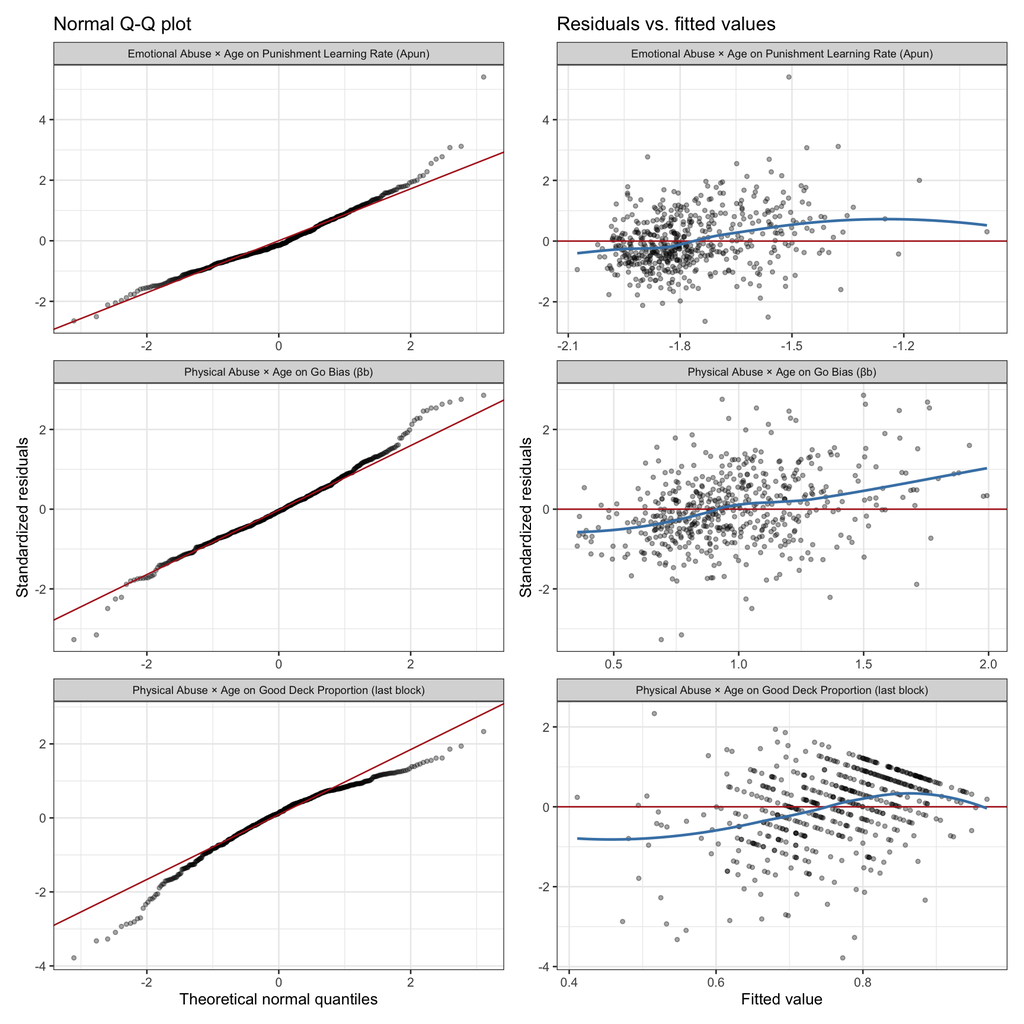

## Supplemental Table 15. Influence analyses for the three adversity effects of interest

The final Model 4 for each effect was re-estimated (a) leaving out each participant in turn (166 refits per effect; Table 15.1) and (b) after removing five participants at a time (Table 15.2). All p-values are uncorrected. The refits below take a few minutes.

### Supplemental Table 15.1. Leave-one-participant-out analysis

| Adversity × Age effect | b, full sample | Range of b across 166 refits | Same direction in all refits | Refits with p < .05 | Largest p across refits | Participants above Cook’s D threshold (4/N) | Largest Cook’s D | Largest \|DFBETAS\| |
| --- | --- | --- | --- | --- | --- | --- | --- | --- |
| Emotional Abuse × Age on Punishment Learning Rate (Apun) | -.009 | -.010 to -.007 | Yes | 100% | .022 | 7 | .098 | .41 |
| Physical Abuse × Age on Go Bias (βb) | -.022 | -.024 to -.020 | Yes | 100% | .023 | 10 | .044 | .33 |
| Physical Abuse × Age on Good Deck Proportion (last block) | -.009 | -.010 to -.007 | Yes | 100% | .010 | 10 | .110 | .62 |

### Supplemental Table 15.2. Re-estimation after removing influential or extreme participants

| Adversity × Age effect | Participants removed | N remaining | b | SE | p-value |
| --- | --- | --- | --- | --- | --- |
| Emotional Abuse × Age on Punishment Learning Rate (Apun) | None (full sample) | 166 | -.009 | .003 | .006 |
|  | Drop the 5 most influential participants (Cook’s D) | 161 | -.009 | .003 | .014 |
|  | Drop the 5 most influential for this interaction (DFBETAS) | 161 | -.010 | .004 | .007 |
|  | Drop the 5 participants with the highest emotional abuse scores | 160 | -.010 | .004 | .021 |
| Physical Abuse × Age on Go Bias (βb) | None (full sample) | 166 | -.022 | .008 | .006 |
|  | Drop the 5 most influential participants (Cook’s D) | 161 | -.020 | .008 | .016 |
|  | Drop the 5 most influential for this interaction (DFBETAS) | 161 | -.018 | .013 | .193 |
|  | Drop the 5 participants with the highest physical abuse scores | 161 | -.020 | .015 | .166 |
| Physical Abuse × Age on Good Deck Proportion (last block) | None (full sample) | 166 | -.009 | .003 | <.001 |
|  | Drop the 5 most influential participants (Cook’s D) | 161 | -.006 | .003 | .048 |
|  | Drop the 5 most influential for this interaction (DFBETAS) | 161 | -.008 | .003 | .017 |
|  | Drop the 5 participants with the highest physical abuse scores | 161 | -.007 | .004 | .075 |

## Supplemental Table 16. Expected change in Net Performance through the learning parameters, by adversity subtype

Model-based estimate of how abuse-related differences in learning could affect Net Performance. For youth 1 SD above and 1 SD below the mean baseline subscale score, the Model 4 growth models predict each learning parameter at each age (9-17 years). The predicted difference in each parameter (in SD units) is multiplied by that parameter’s coefficient from the model with all four parameters together (Supplemental Table 7) and the four products are summed (Total). 95% intervals and p-values are Monte Carlo estimates (10,000 draws). The table shows the slope per year of age [95% CI] of the expected difference in Net Performance (percentage points). Values are model-based extrapolations.

| Adversity Subtype | Learning Predictor | Slope per year [95% CI] | Monte Carlo p-value |
| --- | --- | --- | --- |
| Emotional Abuse | Total (all four learning parameters) | -2.09 [-3.92, -0.24] | .027 |
|  | Reward Learning Rate (Arew) | 0.08 [-0.12, 0.34] | .419 |
|  | Punishment Learning Rate (Apun) | -2.18 [-3.73, -0.65] | .005 |
|  | Win/Loss Frequency Sensitivity (βf) | 0.06 [-0.91, 1.01] | .910 |
|  | Go Bias (βb) | -0.05 [-0.31, 0.16] | .642 |
| Physical Abuse | Total (all four learning parameters) | -1.45 [-3.72, 0.84] | .211 |
|  | Reward Learning Rate (Arew) | 0.22 [-0.02, 0.59] | .082 |
|  | Punishment Learning Rate (Apun) | -1.32 [-3.22, 0.59] | .163 |
|  | Win/Loss Frequency Sensitivity (βf) | -0.01 [-1.14, 1.15] | .995 |
|  | Go Bias (βb) | -0.34 [-1.01, 0.09] | .131 |